# Happiness, PISA & Alcohol

Cornelius Schäfer, Leon Klimpel, Yueling Li

– Note that all code is hidden by default. Click on the “code”-button in the different sections to make it visible.

# Introduction

Our project is based on three studies from 2015. The first one is the ‘World Happiness Report’, which “asks respondents to think of a ladder with the best possible life for them being a 10 and the worst possible life being a 0 and to rate their own current lives on that scale. […] The columns following the happiness score estimate the extent to which each of six factors – economic production, social support, life expectancy, freedom, absence of corruption, and generosity – contribute to making life evaluations higher in each country than they are in Dystopia, […].”

Next is a dataset on the alcohol consumption of people from different countries from the age of 15 and above. Total liters of pure alcohol and different kind of servings, e.g. beer or wine are distinguished.

The last dataset is the PISA – “Program for International Student Assessment” study, which “[…] is applied to 15-year-old students across the world to assess their performance in Math, Reading and Science.”.

# Setup

## Install Packages

– Install Packages if necessary

```r
if(!require(csvread)) install.packages("csvread", repos = "http://cran.us.r-project.org")
if(!require(tidyr)) install.packages("tidyr", repos = "http://cran.us.r-project.org")
if(!require(dplyr)) install.packages("dplyr", repos = "http://cran.us.r-project.org")
```

```r
if(!require(ggplot2)) install.packages("ggplot2", repos = "http://cran.us.r-project.org")
if(!require(ggthemes)) install.packages("ggthemes",repos = "http://cran.us.r-project.org")
if(!require(corrplot)) install.packages("corrplot", repos = "http://cran.us.r-project.org")
if(!require(knitr)) install.packages("knitr", repos = "http://cran.us.r-project.org")
if(!require(gridExtra)) install.packages("gridExtra", repos = "http://cran.us.r-project.org")
if(!require(maps)) install.packages("maps",repos = "http://cran.us.r-project.org")
if(!require(mapproj)) install.packages("mapproj",repos = "http://cran.us.r-project.org")
```

## Load Libraries

– Load needed libraries

```r
library(csvread)
library(tidyr)
library(dplyr)
library(ggplot2)
library(ggthemes)
library(corrplot)
library(knitr)
library(gridExtra)
library(maps)
```

# Clean Data

## Clean PISA Study

The Goal of this section is to clean the data of the PISA-Study Dataset in order to prepare it for the merging with the other datasets.

First we renamed the Columns “ï..Country.Name”, “X2013..YR2013.”, “X2014..YR2014.” and “X2015..YR2015.” to “Country”, “Score.2013”, “Score.2014” and “Score.2015” so we can access them later easier. After that the column “Country.Code” is removed, because we do not need it as the datasets will be joined on the “Country” column. Because the PISA-Study is done every third year, there are no values in the columns for the Score in 2013 and 2014, which is why we removed them as well.

An obstacle is that the different categories (Mathematics, Reading and Science) of the study are in one column, so we had to convert the dataframe from long form to wide form in order to apart them. The Score 2015 was saved in the corresponding column for each category and we only kept the columns for the general Mean Score as the other datasets do not include a separation into female and male participants. Countries who did not take part in the study were removed from the dataset.

As we found out later when merging the datasets, there are countries which are named differend in each study. So we did an anti_join over these datasets and renamed the specific countries to make them standardized.

Finally the general Mean Performance Score was added by calculating the mean of the categories and the clean data was saved in a new CSV-file.

### Setup

#### Read raw data

```r
dfPISA.raw <- read.csv(file = "../data/raw_data/pisa_data.csv", header = TRUE, dec = ".", stringsAsFactors = FALSE)
dfPISA.raw
```

| ï..Country.Name | Country.Code | Series.Name | Series.Code | X2013..YR2013. | X2014..YR2014. | X2015..YR2015. |
| --- | --- | --- | --- | --- | --- | --- |
| Albania | ALB | PISA: Mean performance on the mathematics scale | LO.PISA.MAT | .. | .. | 413.157 |
| Albania | ALB | PISA: Mean performance on the mathematics scale. Female | LO.PISA.MAT.FE | .. | .. | 417.750029482799 |
| Albania | ALB | PISA: Mean performance on the mathematics scale. Male | LO.PISA.MAT.MA | .. | .. | 408.545458736189 |
| Albania | ALB | PISA: Mean performance on the reading scale | LO.PISA.REA | .. | .. | 405.2588 |
| Albania | ALB | PISA: Mean performance on the reading scale. Female | LO.PISA.REA.FE | .. | .. | 434.639625546737 |
| Albania | ALB | PISA: Mean performance on the reading scale. Male | LO.PISA.REA.MA | .. | .. | 375.75919916958 |
| Albania | ALB | PISA: Mean performance on the science scale | LO.PISA.SCI | .. | .. | 427.225 |
| Albania | ALB | PISA: Mean performance on the science scale. Female | LO.PISA.SCI.FE | .. | .. | 439.442962901842 |
| Albania | ALB | PISA: Mean performance on the science scale. Male | LO.PISA.SCI.MA | .. | .. | 414.957643727778 |
| Algeria | DZA | PISA: Mean performance on the mathematics scale | LO.PISA.MAT | .. | .. | 359.6062 |

[output cut: 1156 more lines]

### Clean Data

#### Delete unneccessary columns and rows

```r
tail(dfPISA.raw)
```

|  | ï..Country.Name | Country.Code | Series.Name | Series.Code | X2013..YR2013. | X2014..YR2014. | X2015..YR2015. |
| --- | --- | --- | --- | --- | --- | --- | --- |
| 1161 | Zimbabwe | ZWE | PISA: Mean performance on the science scale. Male | LO.PISA.SCI.MA | .. | .. | .. |
| 1162 |  |  |  |  |  |  |  |
| 1163 |  |  |  |  |  |  |  |
| 1164 |  |  |  |  |  |  |  |
| 1165 | Data from database: Education Statistics: Learning Outcomes |  |  |  |  |  |  |
| 1166 | Last Updated: 12/12/2016 |  |  |  |  |  |  |

```r
n<-dim(dfPISA.raw)[1]
dfPISA.raw<-dfPISA.raw[1:(n-5),]
tail(dfPISA.raw)
```

|  | ï..Country.Name | Country.Code | Series.Name | Series.Code | X2013..YR2013. | X2014..YR2014. | X2015..YR2015. |
| --- | --- | --- | --- | --- | --- | --- | --- |
| 1156 | Zimbabwe | ZWE | PISA: Mean performance on the reading scale | LO.PISA.REA | .. | .. | .. |
| 1157 | Zimbabwe | ZWE | PISA: Mean performance on the reading scale. Female | LO.PISA.REA.FE | .. | .. | .. |
| 1158 | Zimbabwe | ZWE | PISA: Mean performance on the reading scale. Male | LO.PISA.REA.MA | .. | .. | .. |
| 1159 | Zimbabwe | ZWE | PISA: Mean performance on the science scale | LO.PISA.SCI | .. | .. | .. |
| 1160 | Zimbabwe | ZWE | PISA: Mean performance on the science scale. Female | LO.PISA.SCI.FE | .. | .. | .. |
| 1161 | Zimbabwe | ZWE | PISA: Mean performance on the science scale. Male | LO.PISA.SCI.MA | .. | .. | .. |

```r
names(dfPISA.raw)
```

```
## [1] "ï..Country.Name" "Country.Code"    "Series.Name"     "Series.Code"
## [5] "X2013..YR2013."  "X2014..YR2014."  "X2015..YR2015."
```

```r
names(dfPISA.raw)[1] <- "Country"
names(dfPISA.raw)[5] <- "Score.2013"
names(dfPISA.raw)[6] <- "Score.2014"
names(dfPISA.raw)[7] <- "Score.2015"
names(dfPISA.raw)
```

```
## [1] "Country"      "Country.Code" "Series.Name"  "Series.Code"
## [5] "Score.2013"   "Score.2014"   "Score.2015"
```

```r
drops <- c("Country.Code","Series.Code", "Score.2013", "Score.2014")
dfPISA.raw <- dfPISA.raw[ , !(names(dfPISA.raw) %in% drops)]
head(dfPISA.raw)
```

|  | Country | Series.Name | Score.2015 |
| --- | --- | --- | --- |
| 1 | Albania | PISA: Mean performance on the mathematics scale | 413.157 |
| 2 | Albania | PISA: Mean performance on the mathematics scale. Female | 417.750029482799 |
| 3 | Albania | PISA: Mean performance on the mathematics scale. Male | 408.545458736189 |
| 4 | Albania | PISA: Mean performance on the reading scale | 405.2588 |
| 5 | Albania | PISA: Mean performance on the reading scale. Female | 434.639625546737 |
| 6 | Albania | PISA: Mean performance on the reading scale. Male | 375.75919916958 |

#### Apart the different PISA-Categorys

– Apart the Mean Performance of the different Scales – Delete the unneeded “Series.Code”-column  
– Rename the “Score.2015”-column to the name of the Scale  
– Free memory by deleting the old dfPISA.raw frame

```r
dfPISA.clean <- tidyr::spread(dfPISA.raw, Series.Name, Score.2015)
dfPISA.clean
```

| Country | PISA: Mean performance on the mathematics scale | PISA: Mean performance on the mathematics scale. Female | PISA: Mean performance on the mathematics scale. Male | PISA: Mean performance on the reading scale | PISA: Mean performance on the reading scale. Female | PISA: Mean performance on the reading scale. Male | PISA: Mean performance on the science scale | PISA: Mean performance on the science scale. Female | PISA: Mean performance on the science scale. Male |
| --- | --- | --- | --- | --- | --- | --- | --- | --- | --- |
| Albania | 413.157 | 417.750029482799 | 408.545458736189 | 405.2588 | 434.639625546737 | 375.75919916958 | 427.225 | 439.442962901842 | 414.957643727778 |
| Algeria | 359.6062 | 363.072479076874 | 356.495105666181 | 349.8593 | 366.208166798086 | 335.185435908668 | 375.7451 | 383.220938935314 | 369.035233788056 |
| Argentina | 409.0333 | 400.443116055612 | 418.388360865522 | 425.3031 | 432.95807959441 | 416.966607209736 | 432.2262 | 424.994351346692 | 440.102029698007 |
| Armenia | .. | .. | .. | .. | .. | .. | .. | .. | .. |
| Australia | 493.8962 | 490.985500770373 | 496.761344887127 | 502.9006 | 518.865799240277 | 487.18552546683 | 509.9939 | 508.921647404582 | 511.049257232073 |
| Austria | 496.7423 | 483.133026052429 | 510.098215924204 | 484.8656 | 495.075191103096 | 474.846031609294 | 495.0375 | 485.526754333789 | 504.371197291877 |
| Azerbaijan | .. | .. | .. | .. | .. | .. | .. | .. | .. |
| Bahrain | .. | .. | .. | .. | .. | .. | .. | .. | .. |
| Belgium | 506.9844 | 499.739022445487 | 514.002572107543 | 498.5242 | 506.638598758987 | 490.664155783999 | 501.9997 | 496.031867435122 | 507.780477052817 |
| Belize | .. | .. | .. | .. | .. | .. | .. | .. | .. |

[output cut: 119 more lines]

```r
dfPISA.raw <- NULL
```

#### Clean data

– Delete Male and Female Scales as they are not needed when comparing Data Sets for Aclohol Consuption, Happiness Record and PISA Study  
– Rename Scale Columns  
– Delete all rows with countries that have not participated in the PISA study  
– Rename some Countries in order to join the Data Sets later

```r
drops <- c(
  "PISA: Mean performance on the mathematics scale. Female",
  "PISA: Mean performance on the mathematics scale. Male",
  "PISA: Mean performance on the reading scale. Female",
  "PISA: Mean performance on the reading scale. Male",
  "PISA: Mean performance on the science scale. Female",
  "PISA: Mean performance on the science scale. Male")
dfPISA.clean <- dfPISA.clean[ , !(names(dfPISA.clean) %in% drops)]
```

```r
names(dfPISA.clean)[2] <- "PISA.Performance.Mean.Mathematics"
names(dfPISA.clean)[3] <- "PISA.Performance.Mean.Reading"
names(dfPISA.clean)[4] <- "PISA.Performance.Mean.Science"
```

```r
dfPISA.clean <- subset(dfPISA.clean, dfPISA.clean[1] != ".." & dfPISA.clean[2] != ".." & dfPISA.clean[3] != ".." & dfPISA.clean[4] != "..")
```

```r
ind <- which(dfPISA.clean$Country=="Korea, Rep.", arr.in=TRUE)
dfPISA.clean$Country[ind] <- "South Korea"

ind <- which(dfPISA.clean$Country=="Republic of Korea", arr.in=TRUE)
dfPISA.clean$Country[ind] <- "North Korea"

ind <- which(dfPISA.clean$Country=="Macedonia, FYR", arr.in=TRUE)
dfPISA.clean$Country[ind] <- "Macedonia"

ind <- which(dfPISA.clean$Country=="Slovak Republic", arr.in=TRUE)
dfPISA.clean$Country[ind] <- "Slovakia"

dfPISA.clean
```

|  | Country | PISA.Performance.Mean.Mathematics | PISA.Performance.Mean.Reading | PISA.Performance.Mean.Science |
| --- | --- | --- | --- | --- |
| 1 | Albania | 413.157 | 405.2588 | 427.225 |
| 2 | Algeria | 359.6062 | 349.8593 | 375.7451 |
| 3 | Argentina | 409.0333 | 425.3031 | 432.2262 |
| 5 | Australia | 493.8962 | 502.9006 | 509.9939 |
| 6 | Austria | 496.7423 | 484.8656 | 495.0375 |
| 9 | Belgium | 506.9844 | 498.5242 | 501.9997 |
| 15 | Brazil | 377.0695 | 407.3486 | 400.6821 |
| 16 | Bulgaria | 441.1899 | 431.7175 | 445.772 |
| 20 | Canada | 515.6474 | 526.6678 | 527.7047 |
| 22 | Chile | 422.6714 | 458.5709 | 446.9561 |

[output cut: 58 more lines]

#### Calculate PISA Mean Performance

– Convert Scale-Performance to numeric type  
– Calculate PISA Mean Performance for every row  
– Add Value to new column

```r
dfPISA.clean[, c(2,3,4)] <- sapply(dfPISA.clean[, c(2,3,4)], as.numeric)

for (row in 1:nrow(dfPISA.clean)) {
  dfPISA.clean$PISA.Performance.Mean[row] <- (dfPISA.clean$PISA.Performance.Mean.Mathematics[row] + dfPISA.clean$PISA.Performance.Mean.Reading[row] + dfPISA.clean$PISA.Performance.Mean.Science[row]) / 3
}
dfPISA.clean
```

|  | Country | PISA.Performance.Mean.Mathematics | PISA.Performance.Mean.Reading | PISA.Performance.Mean.Science | PISA.Performance.Mean |
| --- | --- | --- | --- | --- | --- |
| 1 | Albania | 413.1570 | 405.2588 | 427.2250 | 415.2136 |
| 2 | Algeria | 359.6062 | 349.8593 | 375.7451 | 361.7369 |
| 3 | Argentina | 409.0333 | 425.3031 | 432.2262 | 422.1875 |
| 5 | Australia | 493.8962 | 502.9006 | 509.9939 | 502.2636 |
| 6 | Austria | 496.7423 | 484.8656 | 495.0375 | 492.2151 |
| 9 | Belgium | 506.9844 | 498.5242 | 501.9997 | 502.5028 |
| 15 | Brazil | 377.0695 | 407.3486 | 400.6821 | 395.0334 |
| 16 | Bulgaria | 441.1899 | 431.7175 | 445.7720 | 439.5598 |
| 20 | Canada | 515.6474 | 526.6678 | 527.7047 | 523.3400 |
| 22 | Chile | 422.6714 | 458.5709 | 446.9561 | 442.7328 |

[output cut: 58 more lines]

#### Save Data in CSV-File

– Write the clean PISA-Data to a CSV-File

```r
write.csv(dfPISA.clean, file = "../data/clean_data/pisa_data.csv",row.names=FALSE, na="", col.names = TRUE)
```

## Clean Happiness Record

The Goal of this section is to clean the data of the Happiness Record 2015 in order to prepare it for the merging with the other datasets.

Like for the other datasets we renamed the columns in order to access them later easier. Because the Happiness Score is made of different categories (which are already in wide form), we chosed to not delete any column as all the data may be useful in the following analysis.

As well as in the other studies again there are some study are countries which are named differend and so we again had to do an anti_join and rename the specific countries. This had to be done because the datasets will be joined on the “Country”-column and so the countries have to be standardized.

Finally the data was saved in a new CSV-file.

### Setup

#### Read raw data

```r
dfHappiness.raw <- read.csv(file = "../data/raw_data/world_happiness_report_2015.csv", header = TRUE)
dfHappiness.raw
```

| Country | Region | Happiness.Rank | Happiness.Score | Standard.Error | Economy..GDP.per.Capita. | Family | Health..Life.Expectancy. | Freedom | Trust..Government.Corruption. | Generosity | Dystopia.Residual |
| --- | --- | --- | --- | --- | --- | --- | --- | --- | --- | --- | --- |
| Switzerland | Western Europe | 1 | 7.587 | 0.03411 | 1.39651 | 1.34951 | 0.94143 | 0.66557 | 0.41978 | 0.29678 | 2.51738 |
| Iceland | Western Europe | 2 | 7.561 | 0.04884 | 1.30232 | 1.40223 | 0.94784 | 0.62877 | 0.14145 | 0.43630 | 2.70201 |
| Denmark | Western Europe | 3 | 7.527 | 0.03328 | 1.32548 | 1.36058 | 0.87464 | 0.64938 | 0.48357 | 0.34139 | 2.49204 |
| Norway | Western Europe | 4 | 7.522 | 0.03880 | 1.45900 | 1.33095 | 0.88521 | 0.66973 | 0.36503 | 0.34699 | 2.46531 |
| Canada | North America | 5 | 7.427 | 0.03553 | 1.32629 | 1.32261 | 0.90563 | 0.63297 | 0.32957 | 0.45811 | 2.45176 |
| Finland | Western Europe | 6 | 7.406 | 0.03140 | 1.29025 | 1.31826 | 0.88911 | 0.64169 | 0.41372 | 0.23351 | 2.61955 |
| Netherlands | Western Europe | 7 | 7.378 | 0.02799 | 1.32944 | 1.28017 | 0.89284 | 0.61576 | 0.31814 | 0.47610 | 2.46570 |
| Sweden | Western Europe | 8 | 7.364 | 0.03157 | 1.33171 | 1.28907 | 0.91087 | 0.65980 | 0.43844 | 0.36262 | 2.37119 |
| New Zealand | Australia and New Zealand | 9 | 7.286 | 0.03371 | 1.25018 | 1.31967 | 0.90837 | 0.63938 | 0.42922 | 0.47501 | 2.26425 |
| Australia | Australia and New Zealand | 10 | 7.284 | 0.04083 | 1.33358 | 1.30923 | 0.93156 | 0.65124 | 0.35637 | 0.43562 | 2.26646 |

[output cut: 148 more lines]

### Clean Data

– Delete the rank column, as it will be incorrect when later merging all studies, because some countries will be dropped.

```r
dfHappiness.raw[3] <- NULL
```

– Renaming columns

```r
names(dfHappiness.raw)[3]<- "Happiness.Score"
names(dfHappiness.raw)[4]<- "Happiness.Score.Standard.Error"
names(dfHappiness.raw)[5]<- "Economy.GDP.per.Capita"
names(dfHappiness.raw)[6]<- "Family"
names(dfHappiness.raw)[7]<- "Health.Life.Expectancy"
names(dfHappiness.raw)[8]<- "Freedom"
names(dfHappiness.raw)[9]<- "Trust.Government.Corruption"
names(dfHappiness.raw)[10]<- "Generosity"
names(dfHappiness.raw)[11]<- "Dystopia.Residual"
```

– rename Countries

```r
ind <- which(levels(dfHappiness.raw$Country)=="Republic of Korea", arr.in=TRUE)
levels(dfHappiness.raw$Country)[ind] <- "North Korea"

ind <- which(levels(dfHappiness.raw$Country)=="Russia", arr.in=TRUE)
levels(dfHappiness.raw$Country)[ind] <- "Russian Federation"

dfHappiness.clean <- dfHappiness.raw
dfHappiness.clean
```

| Country | Region | Happiness.Score | Happiness.Score.Standard.Error | Economy.GDP.per.Capita | Family | Health.Life.Expectancy | Freedom | Trust.Government.Corruption | Generosity | Dystopia.Residual |
| --- | --- | --- | --- | --- | --- | --- | --- | --- | --- | --- |
| Switzerland | Western Europe | 7.587 | 0.03411 | 1.39651 | 1.34951 | 0.94143 | 0.66557 | 0.41978 | 0.29678 | 2.51738 |
| Iceland | Western Europe | 7.561 | 0.04884 | 1.30232 | 1.40223 | 0.94784 | 0.62877 | 0.14145 | 0.43630 | 2.70201 |
| Denmark | Western Europe | 7.527 | 0.03328 | 1.32548 | 1.36058 | 0.87464 | 0.64938 | 0.48357 | 0.34139 | 2.49204 |
| Norway | Western Europe | 7.522 | 0.03880 | 1.45900 | 1.33095 | 0.88521 | 0.66973 | 0.36503 | 0.34699 | 2.46531 |
| Canada | North America | 7.427 | 0.03553 | 1.32629 | 1.32261 | 0.90563 | 0.63297 | 0.32957 | 0.45811 | 2.45176 |
| Finland | Western Europe | 7.406 | 0.03140 | 1.29025 | 1.31826 | 0.88911 | 0.64169 | 0.41372 | 0.23351 | 2.61955 |
| Netherlands | Western Europe | 7.378 | 0.02799 | 1.32944 | 1.28017 | 0.89284 | 0.61576 | 0.31814 | 0.47610 | 2.46570 |
| Sweden | Western Europe | 7.364 | 0.03157 | 1.33171 | 1.28907 | 0.91087 | 0.65980 | 0.43844 | 0.36262 | 2.37119 |
| New Zealand | Australia and New Zealand | 7.286 | 0.03371 | 1.25018 | 1.31967 | 0.90837 | 0.63938 | 0.42922 | 0.47501 | 2.26425 |
| Australia | Australia and New Zealand | 7.284 | 0.04083 | 1.33358 | 1.30923 | 0.93156 | 0.65124 | 0.35637 | 0.43562 | 2.26646 |

[output cut: 148 more lines]

– Write into CSV

```r
write.csv(dfHappiness.clean, file = "../data/clean_data/happiness_data.csv",row.names=FALSE, na="", col.names = TRUE)
```

## Clean GISAH Study (Alcohol Consumption)

The Goal of this section is to clean the data of the Global Information System on Alcohol and Health (GISAH) Dataset in order to prepare it for the merging with the other datasets.

After reading the data from the CSV-File, we renamed the columns in order to access them later easier. Then we removed the columns for years 2010-2014 and 2016 as we only need the Aclohol values of year 2015, because the dataset of the PISA-Study also only contains the Scores of 2015 and we want to join them later so we can analyze the data. The first row of the dataframe was removed as well as it only contains the names of the corresponding columns.

Like the categories in the PISA-Studythe the different beverage types are in one column, so we had to convert the dataframe from long form to wide form in order to apart them. The Alcohol consumption per capita in pure litres for the year 2015 was saved in the corresponding column for each beverage type. In this study are countries which are named differend in the other studies and so we again had to do an anti_join and rename the specific countries to make them standardized.

Last thing we did here was to clear out the “NA”-Values and then the clean data was saved in a new CSV-file.

### Setup

#### Read raw data

```r
dfAlcohol.raw <- read.csv(file ="../data/raw_data/alcohol_consumption.csv", header = TRUE)
dfAlcohol.raw
```

| X | X.1 | X.2 | Alcohol..recorded.per.capita..15...consumption..in.litres.of.pure.alcohol. | Alcohol..recorded.per.capita..15...consumption..in.litres.of.pure.alcohol..1 | Alcohol..recorded.per.capita..15...consumption..in.litres.of.pure.alcohol..2 | Alcohol..recorded.per.capita..15...consumption..in.litres.of.pure.alcohol..3 | Alcohol..recorded.per.capita..15...consumption..in.litres.of.pure.alcohol..4 | Alcohol..recorded.per.capita..15...consumption..in.litres.of.pure.alcohol..5 | Alcohol..recorded.per.capita..15...consumption..in.litres.of.pure.alcohol..6 |
| --- | --- | --- | --- | --- | --- | --- | --- | --- | --- |
| Country | Data Source | Beverage Types | 2016.00 | 2015.00 | 2014.00 | 2013.00 | 2012.00 | 2011.00 | 2010.00 |
| Afghanistan | Data source | All types | NA | 0.02 | 0.03 | 0.03 | 0.04 | 0.04 | 0.03 |
| Afghanistan | Data source | Beer | NA | 0.01 | 0.01 | 0.01 | 0.01 | 0.01 | 0.01 |
| Afghanistan | Data source | Wine | NA | 0.00 | 0.00 | 0.00 | 0.00 | 0.00 | 0.00 |
| Afghanistan | Data source | Spirits | NA | 0.02 | 0.02 | 0.02 | 0.03 | 0.03 | 0.02 |
| Afghanistan | Data source | Other alcoholic beverages | NA | 0.00 | 0.00 | 0.00 | 0.00 | 0.00 | 0.00 |
| Albania | Data source | All types | 5.07 | 4.77 | 4.81 | 5.06 | 5.43 | 5.65 | 5.53 |
| Albania | Data source | Beer | 1.74 | 1.57 | 1.58 | 1.82 | 1.81 | 1.88 | 1.72 |
| Albania | Data source | Wine | 1.34 | 1.17 | 1.12 | 1.06 | 1.30 | 1.27 | 1.30 |
| Albania | Data source | Spirits | 1.90 | 1.94 | 2.02 | 2.09 | 2.22 | 2.40 | 2.39 |

[output cut: 945 more lines]

### Clean data

– Renaming columns  
– Omit superfluous columns: X1: “Datasource”, Years 2016 & 2010-2014

```r
names(dfAlcohol.raw)
```

```
##  [1] "X"
##  [2] "X.1"
##  [3] "X.2"
##  [4] "Alcohol..recorded.per.capita..15...consumption..in.litres.of.pure.alcohol."
##  [5] "Alcohol..recorded.per.capita..15...consumption..in.litres.of.pure.alcohol..1"
##  [6] "Alcohol..recorded.per.capita..15...consumption..in.litres.of.pure.alcohol..2"
##  [7] "Alcohol..recorded.per.capita..15...consumption..in.litres.of.pure.alcohol..3"
##  [8] "Alcohol..recorded.per.capita..15...consumption..in.litres.of.pure.alcohol..4"
##  [9] "Alcohol..recorded.per.capita..15...consumption..in.litres.of.pure.alcohol..5"
## [10] "Alcohol..recorded.per.capita..15...consumption..in.litres.of.pure.alcohol..6"
```

```r
names(dfAlcohol.raw)[1]<- "Country"
names(dfAlcohol.raw)[2]<- "data_source"
names(dfAlcohol.raw)[3]<- "Beverage_Types"
names(dfAlcohol.raw)[4]<- "Alcohol_per_capita_2016"
names(dfAlcohol.raw)[5]<- "Alcohol_per_capita_2015"
names(dfAlcohol.raw)[6]<- "Alcohol_per_capita_2014"
names(dfAlcohol.raw)[7]<- "Alcohol_per_capita_2013"
names(dfAlcohol.raw)[8]<- "Alcohol_per_capita_2012"
names(dfAlcohol.raw)[9]<- "Alcohol_per_capita_2011"
names(dfAlcohol.raw)[10]<- "Alcohol_per_capita_2010"

drops<- c("data_source","Alcohol_per_capita_2016","Alcohol_per_capita_2014","Alcohol_per_capita_2013","Alcohol_per_capita_2012","Alcohol_per_capita_2011","Alcohol_per_capita_2010")
dfAlcohol.2015 <- dfAlcohol.raw[, !names(dfAlcohol.raw) %in% drops]
dfAlcohol.2015
```

| Country | Beverage_Types | Alcohol_per_capita_2015 |
| --- | --- | --- |
| Country | Beverage Types | 2015.00 |
| Afghanistan | All types | 0.02 |
| Afghanistan | Beer | 0.01 |
| Afghanistan | Wine | 0.00 |
| Afghanistan | Spirits | 0.02 |
| Afghanistan | Other alcoholic beverages | 0.00 |
| Albania | All types | 4.77 |
| Albania | Beer | 1.57 |
| Albania | Wine | 1.17 |
| Albania | Spirits | 1.94 |

[output cut: 945 more lines]

– Reordering of row/columns: One row for one country, Beverage Types as single columns

```r
#delete first row
dfAlcohol.2015<- dfAlcohol.2015[-c(1), ]
dfAlcohol.2015
```

|  | Country | Beverage_Types | Alcohol_per_capita_2015 |
| --- | --- | --- | --- |
| 2 | Afghanistan | All types | 0.02 |
| 3 | Afghanistan | Beer | 0.01 |
| 4 | Afghanistan | Wine | 0.00 |
| 5 | Afghanistan | Spirits | 0.02 |
| 6 | Afghanistan | Other alcoholic beverages | 0.00 |
| 7 | Albania | All types | 4.77 |
| 8 | Albania | Beer | 1.57 |
| 9 | Albania | Wine | 1.17 |
| 10 | Albania | Spirits | 1.94 |
| 11 | Albania | Other alcoholic beverages | 0.08 |

[output cut: 944 more lines]

```r
dfAlcohol.2015 <- dfAlcohol.2015[-c(580:587),]
dfAlcohol.clean <- tidyr::spread(dfAlcohol.2015, Beverage_Types, Alcohol_per_capita_2015)
dfAlcohol.clean
```

| Country | All types | Beer | Other alcoholic beverages | Spirits | Wine |
| --- | --- | --- | --- | --- | --- |
| Afghanistan | 0.02 | 0.01 | 0.00 | 0.02 | 0.00 |
| Albania | 4.77 | 1.57 | 0.08 | 1.94 | 1.17 |
| Algeria | 0.56 | 0.31 | 0.00 | 0.10 | 0.14 |
| Andorra | 9.97 | 3.33 | 0.00 | 2.32 | 4.32 |
| Angola | 5.65 | 3.66 | 0.05 | 0.70 | 1.24 |
| Antigua and Barbuda | 8.45 | 2.79 | 0.27 | 3.84 | 1.55 |
| Argentina | 8.42 | 3.36 | 0.87 | 0.81 | 3.38 |
| Armenia | 3.84 | 0.46 | 0.00 | 3.16 | 0.20 |
| Australia | 9.52 | 3.76 | 0.88 | 1.22 | 3.66 |
| Austria | 11.40 | 6.10 | NA | 1.70 | 3.60 |

[output cut: 180 more lines]

–Renaming Columns

```r
names(dfAlcohol.clean)[2] <- "Alcohol.Consumption.All.Types"
names(dfAlcohol.clean)[3] <- "Beer"
names(dfAlcohol.clean)[4] <- "Other"
names(dfAlcohol.clean)[5] <- "Spirits"
names(dfAlcohol.clean)[6] <- "Wine"
names(dfAlcohol.clean)
```

```
## [1] "Country"                       "Alcohol.Consumption.All.Types"
## [3] "Beer"                          "Other"
## [5] "Spirits"                       "Wine"
```

–Renaming Countries

```r
ind <- which(levels(dfAlcohol.clean$Country)=="Democratic People's Republic of Korea", arr.in=TRUE)
levels(dfAlcohol.clean$Country)[ind] <- "South Korea"

ind <- which(levels(dfAlcohol.clean$Country)=="Republic of Korea", arr.in=TRUE)
levels(dfAlcohol.clean$Country)[ind] <- "North Korea"

ind <- which(levels(dfAlcohol.clean$Country)=="The former Yugoslav republic of Macedonia", arr.in=TRUE)
levels(dfAlcohol.clean$Country)[ind] <- "Macedonia"

ind <- which(levels(dfAlcohol.clean$Country)=="Czechia", arr.in=TRUE)
levels(dfAlcohol.clean$Country)[ind] <- "Czech Republic"

ind <- which(levels(dfAlcohol.clean$Country)=="Republic of Moldova", arr.in=TRUE)
levels(dfAlcohol.clean$Country)[ind] <- "Moldova"

ind <- which(levels(dfAlcohol.clean$Country)=="United Kingdom of Great Britain and Northern Ireland", arr.in=TRUE)
levels(dfAlcohol.clean$Country)[ind] <- "United Kingdom"

ind <- which(levels(dfAlcohol.clean$Country)=="United States of America", arr.in=TRUE)
levels(dfAlcohol.clean$Country)[ind] <- "United States"

ind <- which(levels(dfAlcohol.clean$Country)=="Viet Nam", arr.in=TRUE)
levels(dfAlcohol.clean$Country)[ind] <- "Vietnam"
```

–Clearing out NAs

```r
dfAlcohol.clean <- subset(dfAlcohol.clean, !is.na(dfAlcohol.clean$Alcohol.Consumption.All.Types) & !is.na(dfAlcohol.clean$Beer) & !is.na(dfAlcohol.clean$Beer))
dfAlcohol.clean
```

|  | Country | Alcohol.Consumption.All.Types | Beer | Other | Spirits | Wine |
| --- | --- | --- | --- | --- | --- | --- |
| 1 | Afghanistan | 0.02 | 0.01 | 0.00 | 0.02 | 0.00 |
| 2 | Albania | 4.77 | 1.57 | 0.08 | 1.94 | 1.17 |
| 3 | Algeria | 0.56 | 0.31 | 0.00 | 0.10 | 0.14 |
| 4 | Andorra | 9.97 | 3.33 | 0.00 | 2.32 | 4.32 |
| 5 | Angola | 5.65 | 3.66 | 0.05 | 0.70 | 1.24 |
| 6 | Antigua and Barbuda | 8.45 | 2.79 | 0.27 | 3.84 | 1.55 |
| 7 | Argentina | 8.42 | 3.36 | 0.87 | 0.81 | 3.38 |
| 8 | Armenia | 3.84 | 0.46 | 0.00 | 3.16 | 0.20 |
| 9 | Australia | 9.52 | 3.76 | 0.88 | 1.22 | 3.66 |
| 10 | Austria | 11.40 | 6.10 | NA | 1.70 | 3.60 |

[output cut: 167 more lines]

–Write into CSV

```r
write.csv(dfAlcohol.clean, file = "../data/clean_data/alcohol_data.csv",row.names=FALSE, na="", col.names = TRUE)
```

# Merge Data

After reading the cleaned dataset of each study we merged the data by an own developed merge function.  
The data was joined on the “Country”-column and includes data of PISA-Scores 2015, Happiness Record 2015 and its categories and the Acohol consumption of 2015 in pure litres of alcohol for each country that took part in all three studies. In addition to this, we made a minimized Master-Dataset as we do not always need all the data for each analysis.

### Setup

#### Read cleaned CSV Files

– Read CSV File “pisa_data.csv”  
– Read CSV File “alcohol_data.csv”  
– Read CSV File “happiness_data.csv”

```r
dfData.PISA <- read.csv("clean_data/pisa_data.csv", stringsAsFactors = FALSE)
dfData.Alcohol <- read.csv("clean_data/alcohol_data.csv", stringsAsFactors = FALSE)
dfData.Happiness <- read.csv("clean_data/happiness_data.csv", stringsAsFactors = FALSE)

dfData.PISA
```

| Country | PISA.Performance.Mean.Mathematics | PISA.Performance.Mean.Reading | PISA.Performance.Mean.Science | PISA.Performance.Mean |
| --- | --- | --- | --- | --- |
| Albania | 413.1570 | 405.2588 | 427.2250 | 415.2136 |
| Algeria | 359.6062 | 349.8593 | 375.7451 | 361.7369 |
| Argentina | 409.0333 | 425.3031 | 432.2262 | 422.1875 |
| Australia | 493.8962 | 502.9006 | 509.9939 | 502.2636 |
| Austria | 496.7423 | 484.8656 | 495.0375 | 492.2151 |
| Belgium | 506.9844 | 498.5242 | 501.9997 | 502.5028 |
| Brazil | 377.0695 | 407.3486 | 400.6821 | 395.0334 |
| Bulgaria | 441.1899 | 431.7175 | 445.7720 | 439.5598 |
| Canada | 515.6474 | 526.6678 | 527.7047 | 523.3400 |
| Chile | 422.6714 | 458.5709 | 446.9561 | 442.7328 |

[output cut: 58 more lines]

```r
dfData.Alcohol
```

| Country | Alcohol.Consumption.All.Types | Beer | Other | Spirits | Wine |
| --- | --- | --- | --- | --- | --- |
| Afghanistan | 0.02 | 0.01 | 0.00 | 0.02 | 0.00 |
| Albania | 4.77 | 1.57 | 0.08 | 1.94 | 1.17 |
| Algeria | 0.56 | 0.31 | 0.00 | 0.10 | 0.14 |
| Andorra | 9.97 | 3.33 | 0.00 | 2.32 | 4.32 |
| Angola | 5.65 | 3.66 | 0.05 | 0.70 | 1.24 |
| Antigua and Barbuda | 8.45 | 2.79 | 0.27 | 3.84 | 1.55 |
| Argentina | 8.42 | 3.36 | 0.87 | 0.81 | 3.38 |
| Armenia | 3.84 | 0.46 | 0.00 | 3.16 | 0.20 |
| Australia | 9.52 | 3.76 | 0.88 | 1.22 | 3.66 |
| Austria | 11.40 | 6.10 | NA | 1.70 | 3.60 |

[output cut: 167 more lines]

```r
dfData.Happiness
```

| Country | Region | Happiness.Score | Happiness.Score.Standard.Error | Economy.GDP.per.Capita | Family | Health.Life.Expectancy | Freedom | Trust.Government.Corruption | Generosity | Dystopia.Residual |
| --- | --- | --- | --- | --- | --- | --- | --- | --- | --- | --- |
| Switzerland | Western Europe | 7.587 | 0.03411 | 1.39651 | 1.34951 | 0.94143 | 0.66557 | 0.41978 | 0.29678 | 2.51738 |
| Iceland | Western Europe | 7.561 | 0.04884 | 1.30232 | 1.40223 | 0.94784 | 0.62877 | 0.14145 | 0.43630 | 2.70201 |
| Denmark | Western Europe | 7.527 | 0.03328 | 1.32548 | 1.36058 | 0.87464 | 0.64938 | 0.48357 | 0.34139 | 2.49204 |
| Norway | Western Europe | 7.522 | 0.03880 | 1.45900 | 1.33095 | 0.88521 | 0.66973 | 0.36503 | 0.34699 | 2.46531 |
| Canada | North America | 7.427 | 0.03553 | 1.32629 | 1.32261 | 0.90563 | 0.63297 | 0.32957 | 0.45811 | 2.45176 |
| Finland | Western Europe | 7.406 | 0.03140 | 1.29025 | 1.31826 | 0.88911 | 0.64169 | 0.41372 | 0.23351 | 2.61955 |
| Netherlands | Western Europe | 7.378 | 0.02799 | 1.32944 | 1.28017 | 0.89284 | 0.61576 | 0.31814 | 0.47610 | 2.46570 |
| Sweden | Western Europe | 7.364 | 0.03157 | 1.33171 | 1.28907 | 0.91087 | 0.65980 | 0.43844 | 0.36262 | 2.37119 |
| New Zealand | Australia and New Zealand | 7.286 | 0.03371 | 1.25018 | 1.31967 | 0.90837 | 0.63938 | 0.42922 | 0.47501 | 2.26425 |
| Australia | Australia and New Zealand | 7.284 | 0.04083 | 1.33358 | 1.30923 | 0.93156 | 0.65124 | 0.35637 | 0.43562 | 2.26646 |

[output cut: 148 more lines]

### Merge and Arrange Data

#### Merge Data

– Load own R-Functions for Multi-Merge  
– Merge the three Data Sets

```r
source("../r/functions.R")
lsData <- list(dfData.Happiness, dfData.PISA, dfData.Alcohol)
dfData.Master <- multiMerge(lsDF = lsData, bFullJoin = FALSE)
dfData.Master
```

| Country | Region | Happiness.Score | Happiness.Score.Standard.Error | Economy.GDP.per.Capita | Family | Health.Life.Expectancy | Freedom | Trust.Government.Corruption | Generosity | Dystopia.Residual | PISA.Performance.Mean.Mathematics | PISA.Performance.Mean.Reading | PISA.Performance.Mean.Science | PISA.Performance.Mean | Alcohol.Consumption.All.Types | Beer | Other | Spirits | Wine |
| --- | --- | --- | --- | --- | --- | --- | --- | --- | --- | --- | --- | --- | --- | --- | --- | --- | --- | --- | --- |
| Albania | Central and Eastern Europe | 4.959 | 0.05013 | 0.87867 | 0.80434 | 0.81325 | 0.35733 | 0.06413 | 0.14272 | 1.89894 | 413.1570 | 405.2588 | 427.2250 | 415.2136 | 4.77 | 1.57 | 0.08 | 1.94 | 1.17 |
| Algeria | Middle East and Northern Africa | 5.605 | 0.05099 | 0.93929 | 1.07772 | 0.61766 | 0.28579 | 0.17383 | 0.07822 | 2.43209 | 359.6062 | 349.8593 | 375.7451 | 361.7369 | 0.56 | 0.31 | 0.00 | 0.10 | 0.14 |
| Argentina | Latin America and Caribbean | 6.574 | 0.04612 | 1.05351 | 1.24823 | 0.78723 | 0.44974 | 0.08484 | 0.11451 | 2.83600 | 409.0333 | 425.3031 | 432.2262 | 422.1875 | 8.42 | 3.36 | 0.87 | 0.81 | 3.38 |
| Australia | Australia and New Zealand | 7.284 | 0.04083 | 1.33358 | 1.30923 | 0.93156 | 0.65124 | 0.35637 | 0.43562 | 2.26646 | 493.8962 | 502.9006 | 509.9939 | 502.2636 | 9.52 | 3.76 | 0.88 | 1.22 | 3.66 |
| Austria | Western Europe | 7.200 | 0.03751 | 1.33723 | 1.29704 | 0.89042 | 0.62433 | 0.18676 | 0.33088 | 2.53320 | 496.7423 | 484.8656 | 495.0375 | 492.2151 | 11.40 | 6.10 | NA | 1.70 | 3.60 |
| Belgium | Western Europe | 6.937 | 0.03595 | 1.30782 | 1.28566 | 0.89667 | 0.58450 | 0.22540 | 0.22250 | 2.41484 | 506.9844 | 498.5242 | 501.9997 | 502.5028 | 10.36 | 4.60 | 0.32 | 1.47 | 3.97 |
| Brazil | Latin America and Caribbean | 6.983 | 0.04076 | 0.98124 | 1.23287 | 0.69702 | 0.49049 | 0.17521 | 0.14574 | 3.26001 | 377.0695 | 407.3486 | 400.6821 | 395.0334 | 6.97 | 4.45 | 0.03 | 2.24 | 0.25 |
| Bulgaria | Central and Eastern Europe | 4.218 | 0.04828 | 1.01216 | 1.10614 | 0.76649 | 0.30587 | 0.00872 | 0.11921 | 0.89991 | 441.1899 | 431.7175 | 445.7720 | 439.5598 | 11.30 | 4.22 | 0.13 | 4.99 | 1.96 |
| Canada | North America | 7.427 | 0.03553 | 1.32629 | 1.32261 | 0.90563 | 0.63297 | 0.32957 | 0.45811 | 2.45176 | 515.6474 | 526.6678 | 527.7047 | 523.3400 | 8.00 | 3.70 | 0.30 | 2.00 | 2.00 |
| Chile | Latin America and Caribbean | 6.670 | 0.05800 | 1.10715 | 1.12447 | 0.85857 | 0.44132 | 0.12869 | 0.33363 | 2.67585 | 422.6714 | 458.5709 | 446.9561 | 442.7328 | 7.89 | 2.85 | 0.00 | 2.43 | 2.61 |

[output cut: 56 more lines]

#### Arrange Data

– drop not often colums to minimze master data

```r
drops <- c(
  "Happiness.Score.Standard.Error",
  "Freedom",
  "Family",
  "Trust.Government.Corruption",
  "Generosity",
  "Dystopia.Residual",
  "Other",
  "Spirits",
  "Wine",
  "Beer"
)
dfData.Master.min <- dfData.Master[ , !(names(dfData.Master) %in% drops)]
dfData.Master.min
```

| Country | Region | Happiness.Score | Economy.GDP.per.Capita | Health.Life.Expectancy | PISA.Performance.Mean.Mathematics | PISA.Performance.Mean.Reading | PISA.Performance.Mean.Science | PISA.Performance.Mean | Alcohol.Consumption.All.Types |
| --- | --- | --- | --- | --- | --- | --- | --- | --- | --- |
| Albania | Central and Eastern Europe | 4.959 | 0.87867 | 0.81325 | 413.1570 | 405.2588 | 427.2250 | 415.2136 | 4.77 |
| Algeria | Middle East and Northern Africa | 5.605 | 0.93929 | 0.61766 | 359.6062 | 349.8593 | 375.7451 | 361.7369 | 0.56 |
| Argentina | Latin America and Caribbean | 6.574 | 1.05351 | 0.78723 | 409.0333 | 425.3031 | 432.2262 | 422.1875 | 8.42 |
| Australia | Australia and New Zealand | 7.284 | 1.33358 | 0.93156 | 493.8962 | 502.9006 | 509.9939 | 502.2636 | 9.52 |
| Austria | Western Europe | 7.200 | 1.33723 | 0.89042 | 496.7423 | 484.8656 | 495.0375 | 492.2151 | 11.40 |
| Belgium | Western Europe | 6.937 | 1.30782 | 0.89667 | 506.9844 | 498.5242 | 501.9997 | 502.5028 | 10.36 |
| Brazil | Latin America and Caribbean | 6.983 | 0.98124 | 0.69702 | 377.0695 | 407.3486 | 400.6821 | 395.0334 | 6.97 |
| Bulgaria | Central and Eastern Europe | 4.218 | 1.01216 | 0.76649 | 441.1899 | 431.7175 | 445.7720 | 439.5598 | 11.30 |
| Canada | North America | 7.427 | 1.32629 | 0.90563 | 515.6474 | 526.6678 | 527.7047 | 523.3400 | 8.00 |
| Chile | Latin America and Caribbean | 6.670 | 1.10715 | 0.85857 | 422.6714 | 458.5709 | 446.9561 | 442.7328 | 7.89 |

[output cut: 56 more lines]

#### Save CSV-Files

– Save CSV-Files

```r
write.csv(dfData.Master, file = "master_data/master_data.csv",row.names=FALSE, na="", col.names = TRUE)
write.csv(dfData.Master.min, file = "master_data/master_data.min.csv",row.names=FALSE, na="", col.names = TRUE)
```

# The Data

## Maps

### Setup

#### Load Data from CSV

– Load CSVf- files

```r
dfData.PISA <- read.csv("../../../data/clean_data/pisa_data.csv", stringsAsFactors = FALSE)
dfData.Alcohol <- read.csv("../../../data/clean_data/alcohol_data.csv", stringsAsFactors = FALSE)
dfData.Happiness <- read.csv("../../../data/clean_data/happiness_data.csv", stringsAsFactors = FALSE)
```

### Adapt Data

#### Adapt Data to ggplot2-World Map

##### World Data

```r
dfData.World <- ggplot2::map_data('world')
dfData.World <- dplyr::filter(dfData.World, region != "Antarctica")
dfData.World <- ggplot2::fortify(dfData.World)

ind <- which(dfData.World$region=="Trinidad", arr.in=TRUE)
for (country in ind) {
  dfData.World$region[ind] <- "Trinidad and Tobago"
}
ind <- which(dfData.World$region=="Tobago", arr.in=TRUE)
for (country in ind) {
  dfData.World$region[ind] <- "Trinidad and Tobago"
}
dfData.World
```

| long | lat | group | order | region | subregion |
| --- | --- | --- | --- | --- | --- |
| -69.89912415 | 12.452001572 | 1 | 1 | Aruba | NA |
| -69.89570618 | 12.422998428 | 1 | 2 | Aruba | NA |
| -69.94219208 | 12.438525200 | 1 | 3 | Aruba | NA |
| -70.00415039 | 12.500488281 | 1 | 4 | Aruba | NA |
| -70.06611633 | 12.546972275 | 1 | 5 | Aruba | NA |
| -70.05088043 | 12.597069740 | 1 | 6 | Aruba | NA |
| -70.03511047 | 12.614110947 | 1 | 7 | Aruba | NA |
| -69.97314453 | 12.567626953 | 1 | 8 | Aruba | NA |
| -69.91181183 | 12.480468750 | 1 | 9 | Aruba | NA |
| -69.89912415 | 12.452001572 | 1 | 10 | Aruba | NA |

[output cut: 9990 more lines]

##### Alcohol Study

```r
dfData.Alcohol
```

| Country | Alcohol.Consumption.All.Types | Beer | Other | Spirits | Wine |
| --- | --- | --- | --- | --- | --- |
| Afghanistan | 0.02 | 0.01 | 0.00 | 0.02 | 0.00 |
| Albania | 4.77 | 1.57 | 0.08 | 1.94 | 1.17 |
| Algeria | 0.56 | 0.31 | 0.00 | 0.10 | 0.14 |
| Andorra | 9.97 | 3.33 | 0.00 | 2.32 | 4.32 |
| Angola | 5.65 | 3.66 | 0.05 | 0.70 | 1.24 |
| Antigua and Barbuda | 8.45 | 2.79 | 0.27 | 3.84 | 1.55 |
| Argentina | 8.42 | 3.36 | 0.87 | 0.81 | 3.38 |
| Armenia | 3.84 | 0.46 | 0.00 | 3.16 | 0.20 |
| Australia | 9.52 | 3.76 | 0.88 | 1.22 | 3.66 |
| Austria | 11.40 | 6.10 | NA | 1.70 | 3.60 |

[output cut: 167 more lines]

```r
names(dfData.Alcohol)[1] <- "region"
ind <- which(dfData.Alcohol$region=="Russian Federation", arr.in=TRUE)
dfData.Alcohol$region[ind] <- "Russia"
ind <- which(dfData.Alcohol$region=="United Kingdom", arr.in=TRUE)
dfData.Alcohol$region[ind] <- "UK"
ind <- which(dfData.Alcohol$region=="United States", arr.in=TRUE)
dfData.Alcohol$region[ind] <- "USA"
dfData.Alcohol
```

| region | Alcohol.Consumption.All.Types | Beer | Other | Spirits | Wine |
| --- | --- | --- | --- | --- | --- |
| Afghanistan | 0.02 | 0.01 | 0.00 | 0.02 | 0.00 |
| Albania | 4.77 | 1.57 | 0.08 | 1.94 | 1.17 |
| Algeria | 0.56 | 0.31 | 0.00 | 0.10 | 0.14 |
| Andorra | 9.97 | 3.33 | 0.00 | 2.32 | 4.32 |
| Angola | 5.65 | 3.66 | 0.05 | 0.70 | 1.24 |
| Antigua and Barbuda | 8.45 | 2.79 | 0.27 | 3.84 | 1.55 |
| Argentina | 8.42 | 3.36 | 0.87 | 0.81 | 3.38 |
| Armenia | 3.84 | 0.46 | 0.00 | 3.16 | 0.20 |
| Australia | 9.52 | 3.76 | 0.88 | 1.22 | 3.66 |
| Austria | 11.40 | 6.10 | NA | 1.70 | 3.60 |

[output cut: 167 more lines]

##### Happiness Record

```r
names(dfData.Happiness)[1] <- "region"
ind <- which(dfData.Happiness$region=="Russian Federation", arr.in=TRUE)
dfData.Happiness$region[ind] <- "Russia"
ind <- which(dfData.Happiness$region=="United Kingdom", arr.in=TRUE)
dfData.Happiness$region[ind] <- "UK"
ind <- which(dfData.Happiness$region=="United States", arr.in=TRUE)
dfData.Happiness$region[ind] <- "USA"
dfData.Happiness
```

| region | Region | Happiness.Score | Happiness.Score.Standard.Error | Economy.GDP.per.Capita | Family | Health.Life.Expectancy | Freedom | Trust.Government.Corruption | Generosity | Dystopia.Residual |
| --- | --- | --- | --- | --- | --- | --- | --- | --- | --- | --- |
| Switzerland | Western Europe | 7.587 | 0.03411 | 1.39651 | 1.34951 | 0.94143 | 0.66557 | 0.41978 | 0.29678 | 2.51738 |
| Iceland | Western Europe | 7.561 | 0.04884 | 1.30232 | 1.40223 | 0.94784 | 0.62877 | 0.14145 | 0.43630 | 2.70201 |
| Denmark | Western Europe | 7.527 | 0.03328 | 1.32548 | 1.36058 | 0.87464 | 0.64938 | 0.48357 | 0.34139 | 2.49204 |
| Norway | Western Europe | 7.522 | 0.03880 | 1.45900 | 1.33095 | 0.88521 | 0.66973 | 0.36503 | 0.34699 | 2.46531 |
| Canada | North America | 7.427 | 0.03553 | 1.32629 | 1.32261 | 0.90563 | 0.63297 | 0.32957 | 0.45811 | 2.45176 |
| Finland | Western Europe | 7.406 | 0.03140 | 1.29025 | 1.31826 | 0.88911 | 0.64169 | 0.41372 | 0.23351 | 2.61955 |
| Netherlands | Western Europe | 7.378 | 0.02799 | 1.32944 | 1.28017 | 0.89284 | 0.61576 | 0.31814 | 0.47610 | 2.46570 |
| Sweden | Western Europe | 7.364 | 0.03157 | 1.33171 | 1.28907 | 0.91087 | 0.65980 | 0.43844 | 0.36262 | 2.37119 |
| New Zealand | Australia and New Zealand | 7.286 | 0.03371 | 1.25018 | 1.31967 | 0.90837 | 0.63938 | 0.42922 | 0.47501 | 2.26425 |
| Australia | Australia and New Zealand | 7.284 | 0.04083 | 1.33358 | 1.30923 | 0.93156 | 0.65124 | 0.35637 | 0.43562 | 2.26646 |

[output cut: 148 more lines]

##### PISA-Study

```r
names(dfData.PISA)[1] <- "region"
ind <- which(dfData.PISA$region=="Russian Federation", arr.in=TRUE)
dfData.PISA$region[ind] <- "Russia"
ind <- which(dfData.PISA$region=="United Kingdom", arr.in=TRUE)
dfData.PISA$region[ind] <- "UK"
ind <- which(dfData.PISA$region=="United States", arr.in=TRUE)
dfData.PISA$region[ind] <- "USA"
dfData.PISA
```

| region | PISA.Performance.Mean.Mathematics | PISA.Performance.Mean.Reading | PISA.Performance.Mean.Science | PISA.Performance.Mean |
| --- | --- | --- | --- | --- |
| Albania | 413.1570 | 405.2588 | 427.2250 | 415.2136 |
| Algeria | 359.6062 | 349.8593 | 375.7451 | 361.7369 |
| Argentina | 409.0333 | 425.3031 | 432.2262 | 422.1875 |
| Australia | 493.8962 | 502.9006 | 509.9939 | 502.2636 |
| Austria | 496.7423 | 484.8656 | 495.0375 | 492.2151 |
| Belgium | 506.9844 | 498.5242 | 501.9997 | 502.5028 |
| Brazil | 377.0695 | 407.3486 | 400.6821 | 395.0334 |
| Bulgaria | 441.1899 | 431.7175 | 445.7720 | 439.5598 |
| Canada | 515.6474 | 526.6678 | 527.7047 | 523.3400 |
| Chile | 422.6714 | 458.5709 | 446.9561 | 442.7328 |

[output cut: 58 more lines]

### Create Maps

#### World´s Alcohol consumption

– Displays the World´s Alcohol Consumption in pure litres of Alcohol  
– White countries have not participated in the study

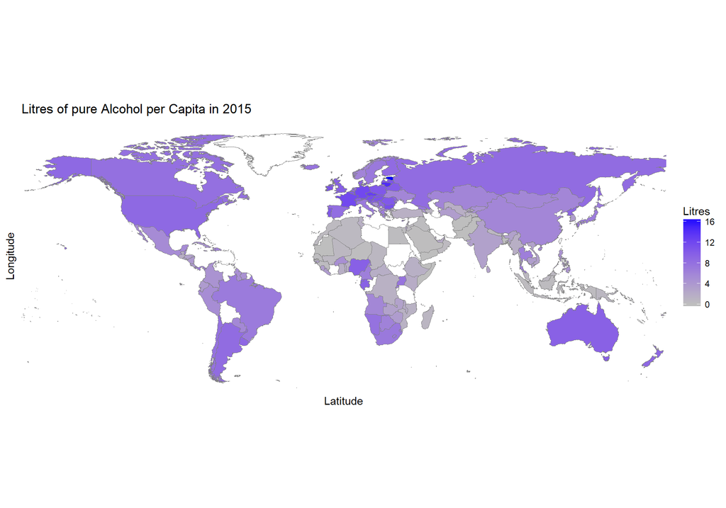

```r
df <- data.frame(region=dfData.Alcohol$region,
                 value=dfData.Alcohol$Alcohol.Consumption.All.Types,
                 stringsAsFactors=FALSE)

p <- ggplot2::ggplot()
p <- p + ggplot2::geom_map(data=dfData.World, map=dfData.World,
                  ggplot2::aes(x=long, y=lat, group=group, map_id=region),
                  fill="white", colour="#7f7f7f", size=0.3)
p <- p + ggplot2::geom_map(data=df, map=dfData.World,
                  ggplot2::aes(fill=value, map_id=region),
                  colour="#7f7f7f", size=0.3)
p <- p + ggplot2::coord_map("rectangular", lat0=0, xlim=c(-180,180), ylim=c(-60, 90))
p <- p + ggplot2::scale_fill_continuous(low="grey", high="blue",
                               guide="colorbar")
p <- p + ggplot2::scale_y_continuous(breaks=c())
p <- p + ggplot2::scale_x_continuous(breaks=c())
p <- p + ggplot2::labs(fill="Litres", title="Litres of pure Alcohol per Capita in 2015", x="Latitude", y="Longitude")
p <- p + ggplot2::theme_bw()
p <- p + ggplot2::theme(panel.border = ggplot2::element_blank())
p
```

#### World´s Happiness Record

– Displays the World´s Happiness record  
– White countries have not participated in the study

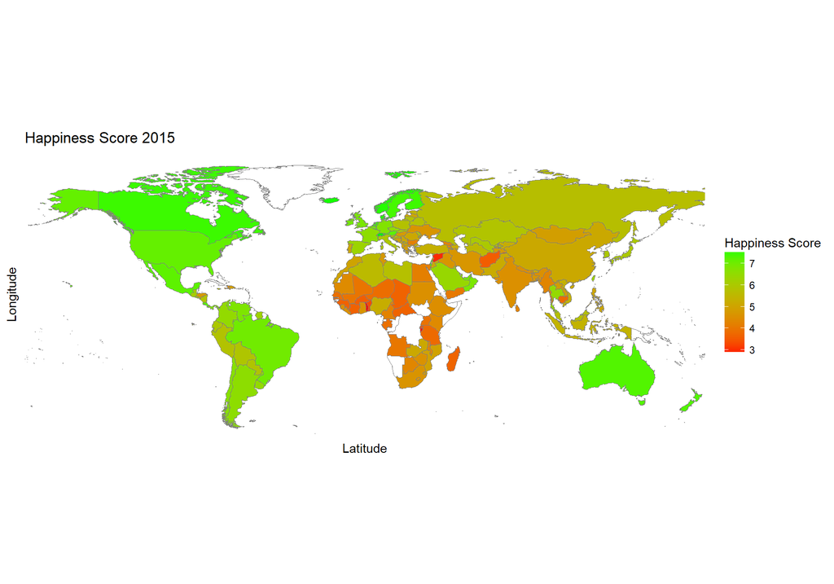

```r
df <- data.frame(region=dfData.Happiness$region,
                 value=dfData.Happiness$Happiness.Score,
                 stringsAsFactors=FALSE)

p <- ggplot2::ggplot()
p <- p + ggplot2::geom_map(data=dfData.World, map=dfData.World,
                  ggplot2::aes(x=long, y=lat, group=group, map_id=region),
                  fill="white", colour="#7f7f7f", size=0.3)
p <- p + ggplot2::geom_map(data=df, map=dfData.World,
                  ggplot2::aes(fill=value, map_id=region),
                  colour="#7f7f7f", size=0.3)
p <- p + ggplot2::coord_map("rectangular", lat0=0, xlim=c(-180,180), ylim=c(-60, 90))
p <- p + ggplot2::scale_fill_continuous(low="red", high="green",
                               guide="colorbar")
p <- p + ggplot2::scale_y_continuous(breaks=c())
p <- p + ggplot2::scale_x_continuous(breaks=c())
p <- p + ggplot2::labs(fill="Happiness Score", title="Happiness Score 2015", x="Latitude", y="Longitude")
p <- p + ggplot2::theme_bw()
p <- p + ggplot2::theme(panel.border = ggplot2::element_blank())
p
```

#### PISA-Study Map

– Displays Mean Performance of the PISA-Study  
– White countries have not participated in the study

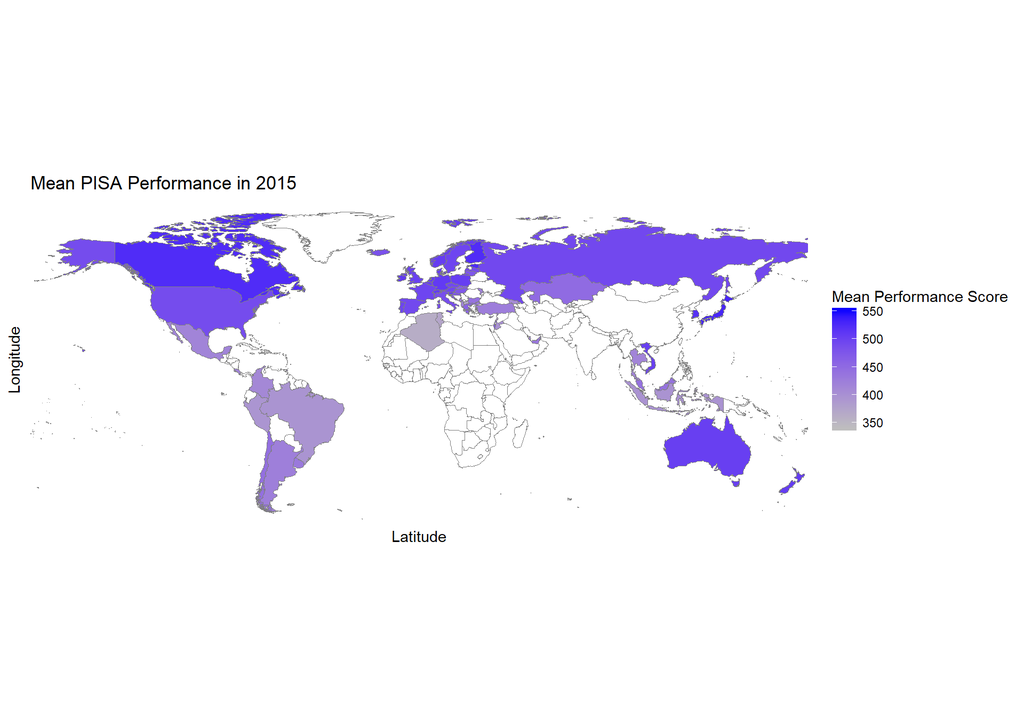

```r
df <- data.frame(region=dfData.PISA$region,
                 value=dfData.PISA$PISA.Performance.Mean,
                 stringsAsFactors=FALSE)

p <- ggplot2::ggplot()
p <- p + ggplot2::geom_map(data=dfData.World, map=dfData.World,
                  ggplot2::aes(x=long, y=lat, group=group, map_id=region),
                  fill="white", colour="#7f7f7f", size=0.3)
p <- p + ggplot2::geom_map(data=df, map=dfData.World,
                  ggplot2::aes(fill=value, map_id=region),
                  colour="#7f7f7f", size=0.3)
p <- p + ggplot2::coord_map("rectangular", lat0=0, xlim=c(-180,180), ylim=c(-60, 90))
p <- p + ggplot2::scale_fill_continuous(low="grey", high="blue",
                               guide="colorbar")
p <- p + ggplot2::scale_y_continuous(breaks=c())
p <- p + ggplot2::scale_x_continuous(breaks=c())
p <- p + ggplot2::labs(fill="Mean Performance Score", title="Mean PISA Performance in 2015", x="Latitude", y="Longitude")
p <- p + ggplot2::theme_bw()
p <- p + ggplot2::theme(panel.border = ggplot2::element_blank())
p
```

## Regions

### Setup

#### Read Data

```r
dfData.Master <- read.csv("../../../data/master_data/master_data.csv")
dfData.Master
```

| Country | Region | Happiness.Score | Happiness.Score.Standard.Error | Economy.GDP.per.Capita | Family | Health.Life.Expectancy | Freedom | Trust.Government.Corruption | Generosity | Dystopia.Residual | PISA.Performance.Mean.Mathematics | PISA.Performance.Mean.Reading | PISA.Performance.Mean.Science | PISA.Performance.Mean | Alcohol.Consumption.All.Types | Beer | Other | Spirits | Wine |
| --- | --- | --- | --- | --- | --- | --- | --- | --- | --- | --- | --- | --- | --- | --- | --- | --- | --- | --- | --- |
| Albania | Central and Eastern Europe | 4.959 | 0.05013 | 0.87867 | 0.80434 | 0.81325 | 0.35733 | 0.06413 | 0.14272 | 1.89894 | 413.1570 | 405.2588 | 427.2250 | 415.2136 | 4.77 | 1.57 | 0.08 | 1.94 | 1.17 |
| Algeria | Middle East and Northern Africa | 5.605 | 0.05099 | 0.93929 | 1.07772 | 0.61766 | 0.28579 | 0.17383 | 0.07822 | 2.43209 | 359.6062 | 349.8593 | 375.7451 | 361.7369 | 0.56 | 0.31 | 0.00 | 0.10 | 0.14 |
| Argentina | Latin America and Caribbean | 6.574 | 0.04612 | 1.05351 | 1.24823 | 0.78723 | 0.44974 | 0.08484 | 0.11451 | 2.83600 | 409.0333 | 425.3031 | 432.2262 | 422.1875 | 8.42 | 3.36 | 0.87 | 0.81 | 3.38 |
| Australia | Australia and New Zealand | 7.284 | 0.04083 | 1.33358 | 1.30923 | 0.93156 | 0.65124 | 0.35637 | 0.43562 | 2.26646 | 493.8962 | 502.9006 | 509.9939 | 502.2636 | 9.52 | 3.76 | 0.88 | 1.22 | 3.66 |
| Austria | Western Europe | 7.200 | 0.03751 | 1.33723 | 1.29704 | 0.89042 | 0.62433 | 0.18676 | 0.33088 | 2.53320 | 496.7423 | 484.8656 | 495.0375 | 492.2151 | 11.40 | 6.10 | NA | 1.70 | 3.60 |
| Belgium | Western Europe | 6.937 | 0.03595 | 1.30782 | 1.28566 | 0.89667 | 0.58450 | 0.22540 | 0.22250 | 2.41484 | 506.9844 | 498.5242 | 501.9997 | 502.5028 | 10.36 | 4.60 | 0.32 | 1.47 | 3.97 |
| Brazil | Latin America and Caribbean | 6.983 | 0.04076 | 0.98124 | 1.23287 | 0.69702 | 0.49049 | 0.17521 | 0.14574 | 3.26001 | 377.0695 | 407.3486 | 400.6821 | 395.0334 | 6.97 | 4.45 | 0.03 | 2.24 | 0.25 |
| Bulgaria | Central and Eastern Europe | 4.218 | 0.04828 | 1.01216 | 1.10614 | 0.76649 | 0.30587 | 0.00872 | 0.11921 | 0.89991 | 441.1899 | 431.7175 | 445.7720 | 439.5598 | 11.30 | 4.22 | 0.13 | 4.99 | 1.96 |
| Canada | North America | 7.427 | 0.03553 | 1.32629 | 1.32261 | 0.90563 | 0.63297 | 0.32957 | 0.45811 | 2.45176 | 515.6474 | 526.6678 | 527.7047 | 523.3400 | 8.00 | 3.70 | 0.30 | 2.00 | 2.00 |
| Chile | Latin America and Caribbean | 6.670 | 0.05800 | 1.10715 | 1.12447 | 0.85857 | 0.44132 | 0.12869 | 0.33363 | 2.67585 | 422.6714 | 458.5709 | 446.9561 | 442.7328 | 7.89 | 2.85 | 0.00 | 2.43 | 2.61 |

[output cut: 56 more lines]

### Select relevant columns for regional analysis

– Too many countries for plot analysis, therefore we take the respective regions as categories

```r
dfData.Master.Regions <- select(dfData.Master, -Country, Happiness.Score.Standard.Error)
dfData.Master.Regions
```

| Region | Happiness.Score | Happiness.Score.Standard.Error | Economy.GDP.per.Capita | Family | Health.Life.Expectancy | Freedom | Trust.Government.Corruption | Generosity | Dystopia.Residual | PISA.Performance.Mean.Mathematics | PISA.Performance.Mean.Reading | PISA.Performance.Mean.Science | PISA.Performance.Mean | Alcohol.Consumption.All.Types | Beer | Other | Spirits | Wine |
| --- | --- | --- | --- | --- | --- | --- | --- | --- | --- | --- | --- | --- | --- | --- | --- | --- | --- | --- |
| Central and Eastern Europe | 4.959 | 0.05013 | 0.87867 | 0.80434 | 0.81325 | 0.35733 | 0.06413 | 0.14272 | 1.89894 | 413.1570 | 405.2588 | 427.2250 | 415.2136 | 4.77 | 1.57 | 0.08 | 1.94 | 1.17 |
| Middle East and Northern Africa | 5.605 | 0.05099 | 0.93929 | 1.07772 | 0.61766 | 0.28579 | 0.17383 | 0.07822 | 2.43209 | 359.6062 | 349.8593 | 375.7451 | 361.7369 | 0.56 | 0.31 | 0.00 | 0.10 | 0.14 |
| Latin America and Caribbean | 6.574 | 0.04612 | 1.05351 | 1.24823 | 0.78723 | 0.44974 | 0.08484 | 0.11451 | 2.83600 | 409.0333 | 425.3031 | 432.2262 | 422.1875 | 8.42 | 3.36 | 0.87 | 0.81 | 3.38 |
| Australia and New Zealand | 7.284 | 0.04083 | 1.33358 | 1.30923 | 0.93156 | 0.65124 | 0.35637 | 0.43562 | 2.26646 | 493.8962 | 502.9006 | 509.9939 | 502.2636 | 9.52 | 3.76 | 0.88 | 1.22 | 3.66 |
| Western Europe | 7.200 | 0.03751 | 1.33723 | 1.29704 | 0.89042 | 0.62433 | 0.18676 | 0.33088 | 2.53320 | 496.7423 | 484.8656 | 495.0375 | 492.2151 | 11.40 | 6.10 | NA | 1.70 | 3.60 |
| Western Europe | 6.937 | 0.03595 | 1.30782 | 1.28566 | 0.89667 | 0.58450 | 0.22540 | 0.22250 | 2.41484 | 506.9844 | 498.5242 | 501.9997 | 502.5028 | 10.36 | 4.60 | 0.32 | 1.47 | 3.97 |
| Latin America and Caribbean | 6.983 | 0.04076 | 0.98124 | 1.23287 | 0.69702 | 0.49049 | 0.17521 | 0.14574 | 3.26001 | 377.0695 | 407.3486 | 400.6821 | 395.0334 | 6.97 | 4.45 | 0.03 | 2.24 | 0.25 |
| Central and Eastern Europe | 4.218 | 0.04828 | 1.01216 | 1.10614 | 0.76649 | 0.30587 | 0.00872 | 0.11921 | 0.89991 | 441.1899 | 431.7175 | 445.7720 | 439.5598 | 11.30 | 4.22 | 0.13 | 4.99 | 1.96 |
| North America | 7.427 | 0.03553 | 1.32629 | 1.32261 | 0.90563 | 0.63297 | 0.32957 | 0.45811 | 2.45176 | 515.6474 | 526.6678 | 527.7047 | 523.3400 | 8.00 | 3.70 | 0.30 | 2.00 | 2.00 |
| Latin America and Caribbean | 6.670 | 0.05800 | 1.10715 | 1.12447 | 0.85857 | 0.44132 | 0.12869 | 0.33363 | 2.67585 | 422.6714 | 458.5709 | 446.9561 | 442.7328 | 7.89 | 2.85 | 0.00 | 2.43 | 2.61 |

[output cut: 56 more lines]

#### Box-Plots

##### Happines Record

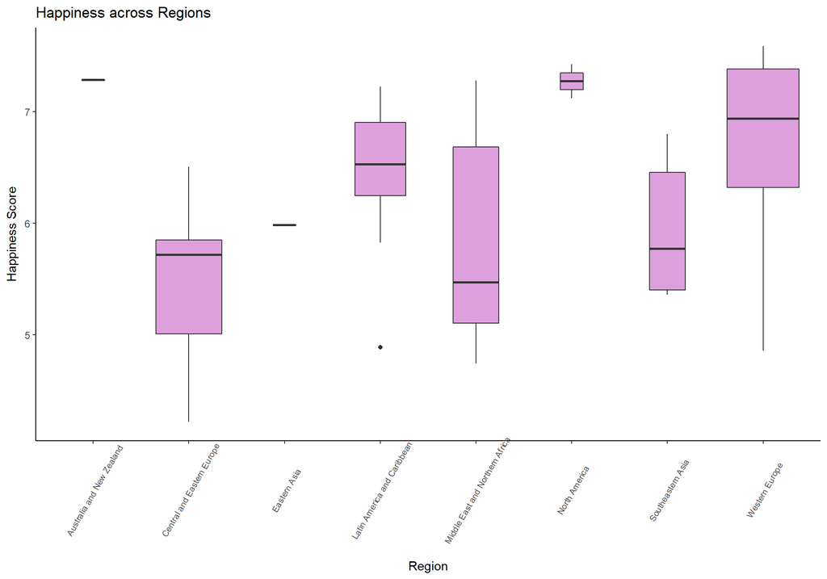

```r
theme_set(theme_classic())

pBox.Happiness<- ggplot(dfData.Master.Regions, aes(Region, Happiness.Score))

pBox.Happiness + geom_boxplot(varwidth = T,   fill="plum") +
  theme(axis.text.x = element_text(angle=60, vjust = 0.6, size = 7.5))+
  labs(title="Happiness across Regions",
       x="Region",
       y="Happiness Score")
```

We can see that people in North America are amongst the happiest, without huge deviation. That is explained by the fact, that only the USA and Canada accord to North America. Western Eruope Followed by Western Europe, with a bigger deviation, especially some in the lowest 25%, overall deviating for over two score points. Middle East and Northern Africa and Central and Eastern Europe also have stronger deviation of over two score points in general, central and Eastern Europe having the unhappiest country.

##### Alcohol Consumption

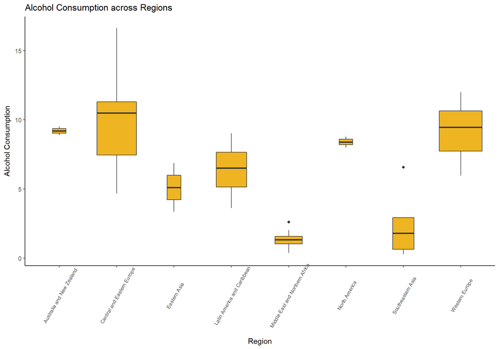

```r
theme_set(theme_classic())

pBox.Alcohol<- ggplot(dfData.Master.Regions, aes(Region, Alcohol.Consumption.All.Types))

pBox.Alcohol + geom_boxplot(varwidth = T,   fill="goldenrod2") +
  theme(axis.text.x = element_text(angle=60, vjust = 0.6, size = 7.5))+
  labs(title="Alcohol Consumption across Regions",
       x="Region",
       y="Alcohol Consumption")
```

We can see Central and Eastern Europe having the highest deviation of over 10 litres per person and the highest alcohol consuming countries. Australia and New Zealand, North America and Western Europe have smiliar mean values, with Western Europe having a span of about 5 litres. In the Middle East, Northern Africa and Southern Asia people tend to drink only little amounts of alcohol. Eastern Asia, Latin America and Caribbean beeing in the middle of all that.

##### PISA-Study

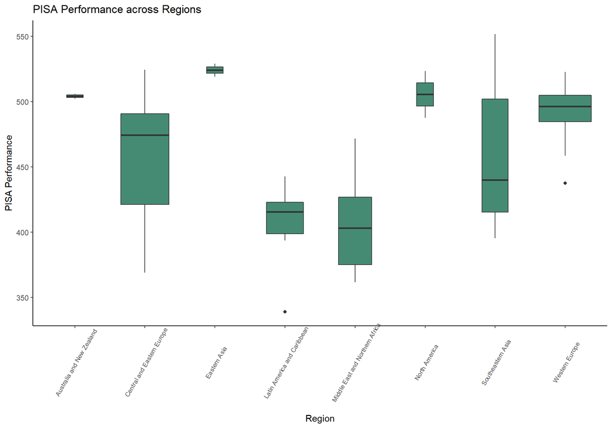

```r
theme_set(theme_classic())

pBox.PISA<- ggplot(dfData.Master.Regions, aes(Region, PISA.Performance.Mean))

pBox.PISA + geom_boxplot(varwidth = T,   fill="aquamarine4") +
  theme(axis.text.x = element_text(angle=60, vjust = 0.6, size = 7.5))+
  labs(title="PISA Performance across Regions",
       x="Region",
       y="PISA Performance")
```

We can see Eastern Asia, Australia and New Zealand, North America and Western Europe with the highest means, leaded by Eastern Asia. Following them we see Central and Eastern Europe and Southeastern Asia with comparable high spans of up to around 150 points. Lowest countries in this category are from latin America and Caribbean and Middle East and Northern Africa.

#### Regional Tops

##### Happiness Record

Preparing the dataset for binning

```r
dfData.Master.Happiness<- select(dfData.Master, Region,Happiness.Score, 5:10)
dfData.Master.Happiness<-dfData.Master.Happiness%>%
  group_by(Region)%>%
  summarise_all(funs(mean))

dfData.Master.Happiness
```

| Region | Happiness.Score | Economy.GDP.per.Capita | Family | Health.Life.Expectancy | Freedom | Trust.Government.Corruption | Generosity |
| --- | --- | --- | --- | --- | --- | --- | --- |
| Australia and New Zealand | 7.285000 | 1.291880 | 1.3144500 | 0.9199650 | 0.6453100 | 0.39279500 | 0.4553150 |
| Central and Eastern Europe | 5.423000 | 1.038486 | 1.0698218 | 0.7507924 | 0.3680871 | 0.07066471 | 0.1298076 |
| Eastern Asia | 5.985500 | 1.257675 | 1.1074300 | 0.9782450 | 0.4141150 | 0.12958500 | 0.1463100 |
| Latin America and Caribbean | 6.447900 | 1.010588 | 1.1537190 | 0.7533150 | 0.5185920 | 0.12181000 | 0.2091100 |
| Middle East and Northern Africa | 5.812125 | 1.144410 | 0.9888175 | 0.7679525 | 0.4021938 | 0.19617250 | 0.1894825 |
| North America | 7.273000 | 1.360400 | 1.2848600 | 0.8837100 | 0.5895050 | 0.24423500 | 0.4295800 |
| Southeastern Asia | 5.956400 | 1.014810 | 1.0709220 | 0.7744760 | 0.5379900 | 0.14667800 | 0.3804100 |
| Western Europe | 6.739350 | 1.303122 | 1.2561630 | 0.9084275 | 0.5529090 | 0.23589600 | 0.3041295 |

```r
dfData.bin.Happiness <- gather(dfData.Master.Happiness, Happiness.Reasons, Amount, 3:8 )
dfData.bin.Happiness <- select(dfData.bin.Happiness, Region,Happiness.Reasons, Amount)
dfData.bin.Happiness
```

| Region | Happiness.Reasons | Amount |
| --- | --- | --- |
| Australia and New Zealand | Economy.GDP.per.Capita | 1.29188000 |
| Central and Eastern Europe | Economy.GDP.per.Capita | 1.03848647 |
| Eastern Asia | Economy.GDP.per.Capita | 1.25767500 |
| Latin America and Caribbean | Economy.GDP.per.Capita | 1.01058800 |
| Middle East and Northern Africa | Economy.GDP.per.Capita | 1.14441000 |
| North America | Economy.GDP.per.Capita | 1.36040000 |
| Southeastern Asia | Economy.GDP.per.Capita | 1.01481000 |
| Western Europe | Economy.GDP.per.Capita | 1.30312250 |
| Australia and New Zealand | Family | 1.31445000 |
| Central and Eastern Europe | Family | 1.06982176 |

[output cut: 38 more lines]

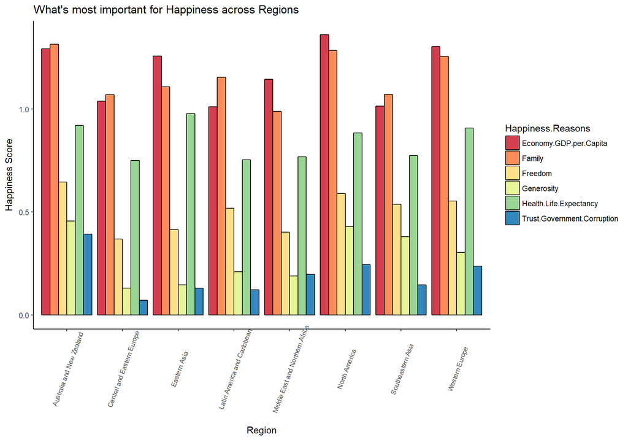

```r
theme_set(theme_classic())

pHappiness.Dodge <- ggplot(dfData.bin.Happiness, aes(Region, Amount))

pHappiness.Dodge + geom_bar(aes(fill=Happiness.Reasons), position = "dodge", stat="identity", color="black")+
  theme(axis.text.x = element_text(angle=70, vjust = 0.6, size = 7.5))+
  scale_fill_brewer(palette="Spectral")+
  labs(title="What's most important for Happiness across Regions",
       x="Region",
       y="Happiness Score")
```

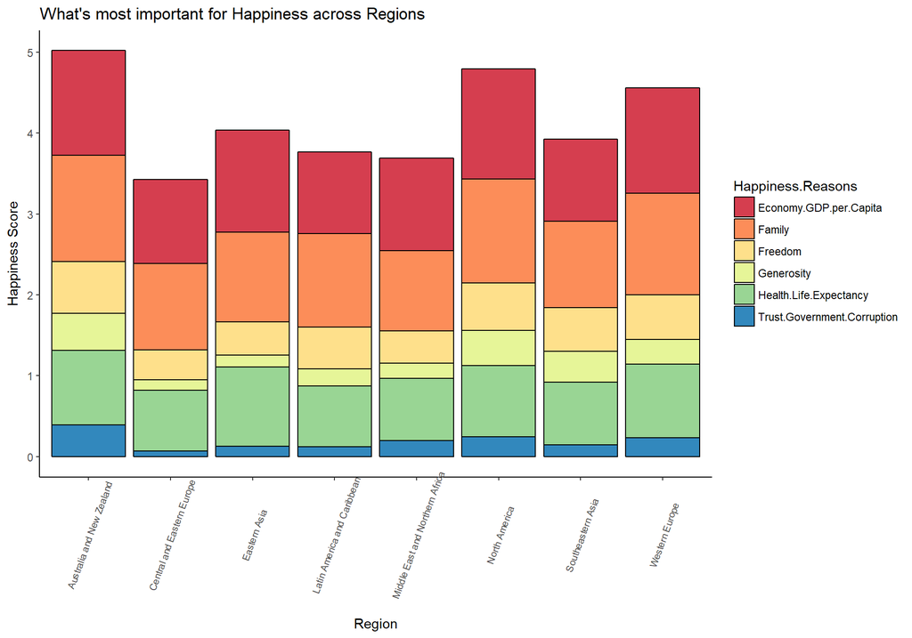

```r
theme_set(theme_classic())

pHappiness.Stack <- ggplot(dfData.bin.Happiness, aes(Region, Amount))

pHappiness.Stack + geom_bar(aes(fill=Happiness.Reasons), position = "stack", stat="identity",color="black")+
  theme(axis.text.x = element_text(angle=70, vjust = 0.6, size = 7.5))+
  scale_fill_brewer(palette="Spectral")+
  labs(title="What's most important for Happiness across Regions",
       x="Region",
       y="Happiness Score")
```

##### Alcohol Consumption

```r
dfData.Master.Alcohol<- select(dfData.Master, Region, 16:20)

dfData.Master.Alcohol<-dfData.Master.Alcohol%>%
  group_by(Region)%>%
  summarise_all(funs(mean(.,na.rm = TRUE)))

dfData.Master.Alcohol
```

| Region | Alcohol.Consumption.All.Types | Beer | Other | Spirits | Wine |
| --- | --- | --- | --- | --- | --- |
| Australia and New Zealand | 9.195000 | 3.555000 | 0.4550000 | 1.875000 | 3.315000 |
| Central and Eastern Europe | 9.797647 | 3.715294 | 0.3812500 | 3.412941 | 2.311765 |
| Eastern Asia | 5.105000 | 0.670000 | 1.2450000 | 3.000000 | 0.190000 |
| Latin America and Caribbean | 6.376000 | 3.357000 | 0.1180000 | 1.751000 | 1.151000 |
| Middle East and Northern Africa | 1.353750 | 0.568750 | 0.0112500 | 0.627500 | 0.147500 |
| North America | 8.390000 | 3.915000 | 0.3000000 | 2.535000 | 1.795000 |
| Southeastern Asia | 2.442000 | 1.244000 | 0.0080000 | 1.026000 | 0.164000 |
| Western Europe | 9.220500 | 3.597500 | 0.2316667 | 1.795000 | 3.621000 |

```r
dfData.bin.Alcohol <- gather(dfData.Master.Alcohol, Alcohol.Types, Amount, 3:6 )
dfData.bin.Alcohol <- select(dfData.bin.Alcohol, Region,Alcohol.Types, Amount)
dfData.bin.Alcohol
```

| Region | Alcohol.Types | Amount |
| --- | --- | --- |
| Australia and New Zealand | Beer | 3.5550000 |
| Central and Eastern Europe | Beer | 3.7152941 |
| Eastern Asia | Beer | 0.6700000 |
| Latin America and Caribbean | Beer | 3.3570000 |
| Middle East and Northern Africa | Beer | 0.5687500 |
| North America | Beer | 3.9150000 |
| Southeastern Asia | Beer | 1.2440000 |
| Western Europe | Beer | 3.5975000 |
| Australia and New Zealand | Other | 0.4550000 |
| Central and Eastern Europe | Other | 0.3812500 |

[output cut: 22 more lines]

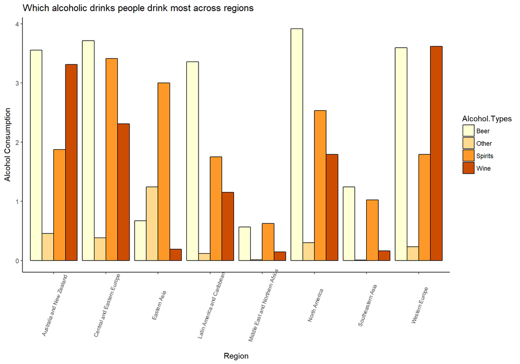

```r
theme_set(theme_classic())

pAlcohol.Dodge <- ggplot(dfData.bin.Alcohol, aes(Region, Amount))

pAlcohol.Dodge + geom_bar(aes(fill=Alcohol.Types), position ="dodge", stat="identity",color="black")+
  theme(axis.text.x = element_text(angle=70, vjust = 0.6, size = 7.5))+
  scale_fill_brewer(palette="YlOrBr")+
  labs(title="Which alcoholic drinks people drink most across regions",
       x="Region",
       y="Alcohol Consumption")
```

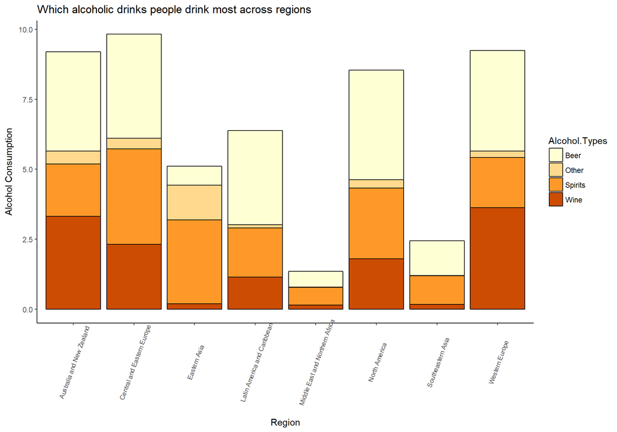

```r
theme_set(theme_classic())

pAlcohol.Stack <- ggplot(dfData.bin.Alcohol, aes(Region, Amount))

pAlcohol.Stack + geom_bar(aes(fill=Alcohol.Types), position ="stack", stat="identity",color="black")+
  theme(axis.text.x = element_text(angle=70, vjust = 0.6, size = 7.5))+
  scale_fill_brewer(palette="YlOrBr")+
  labs(title="Which alcoholic drinks people drink most across regions",
       x="Region",
       y="Alcohol Consumption")
```

##### PISA-Study

```r
dfData.Master.PISA<- select(dfData.Master, Region, 12:15)

dfData.Master.PISA<-dfData.Master.PISA%>%
  group_by(Region)%>%
  summarise_all(funs(mean(.,na.rm = TRUE)))

dfData.Master.PISA
```

| Region | PISA.Performance.Mean.Mathematics | PISA.Performance.Mean.Reading | PISA.Performance.Mean.Science | PISA.Performance.Mean |
| --- | --- | --- | --- | --- |
| Australia and New Zealand | 494.5598 | 506.0856 | 511.6487 | 504.0980 |
| Central and Eastern Europe | 460.2352 | 455.3682 | 462.9475 | 459.5170 |
| Eastern Asia | 528.2731 | 516.6976 | 527.1024 | 524.0243 |
| Latin America and Caribbean | 395.6193 | 418.6016 | 411.9187 | 408.7132 |
| Middle East and Northern Africa | 402.8675 | 401.0364 | 412.9610 | 405.6216 |
| North America | 492.6379 | 511.8015 | 511.9735 | 505.4710 |
| Southeastern Asia | 461.2782 | 451.7684 | 469.5207 | 460.8558 |
| Western Europe | 493.0278 | 492.1654 | 491.7105 | 492.3013 |

```r
dfData.bin.PISA <- gather(dfData.Master.PISA, PISA.Disciplines, Amount, 2:4 )
dfData.bin.PISA<- select(dfData.bin.PISA, Region,PISA.Disciplines, Amount)
dfData.bin.PISA
```

| Region | PISA.Disciplines | Amount |
| --- | --- | --- |
| Australia and New Zealand | PISA.Performance.Mean.Mathematics | 494.5598 |
| Central and Eastern Europe | PISA.Performance.Mean.Mathematics | 460.2352 |
| Eastern Asia | PISA.Performance.Mean.Mathematics | 528.2731 |
| Latin America and Caribbean | PISA.Performance.Mean.Mathematics | 395.6193 |
| Middle East and Northern Africa | PISA.Performance.Mean.Mathematics | 402.8675 |
| North America | PISA.Performance.Mean.Mathematics | 492.6379 |
| Southeastern Asia | PISA.Performance.Mean.Mathematics | 461.2782 |
| Western Europe | PISA.Performance.Mean.Mathematics | 493.0278 |
| Australia and New Zealand | PISA.Performance.Mean.Reading | 506.0856 |
| Central and Eastern Europe | PISA.Performance.Mean.Reading | 455.3682 |

[output cut: 14 more lines]

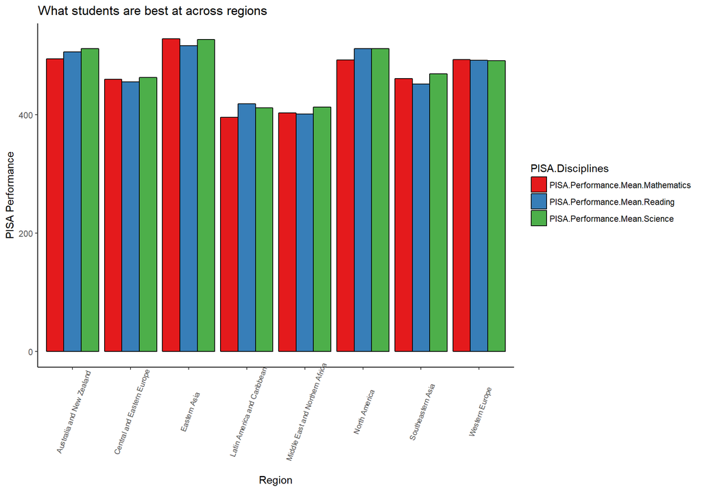

```r
theme_set(theme_classic())

pPISA.Dodge<- ggplot(dfData.bin.PISA, aes(Region, Amount))

pPISA.Dodge + geom_bar(aes(fill=PISA.Disciplines), position = "dodge", stat="identity",color="black")+
  theme(axis.text.x = element_text(angle=70, vjust = 0.6, size = 7.5))+
  scale_fill_brewer(palette="Set1")+
  labs(title="What students are best at across regions",
       x="Region",
       y="PISA Performance")
```

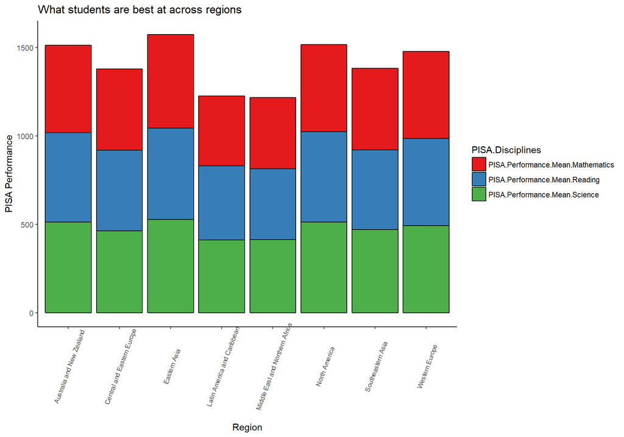

```r
theme_set(theme_classic())

pPISA.Stack<- ggplot(dfData.bin.PISA, aes(Region, Amount))

pPISA.Stack + geom_bar(aes(fill=PISA.Disciplines), position = "stack", stat="identity",color="black")+
  theme(axis.text.x = element_text(angle=70, vjust = 0.6, size = 7.5))+
  scale_fill_brewer(palette="Set1")+
  labs(title="What students are best at across regions",
       x="Region",
       y="PISA Performance")
```

## Top/Bottom Ten Countries

### Setup

#### Read cleaned CSV Files

```r
dfData.master <- read.csv("../../../data/master_data/master_data.min.csv")
```

### Top Ten Countries in different Studies 2015

– This Top-Ten-Lists contain the countries which participated in all 3 studies (Happiness Record, PISA-Study, Alcohol Consumption Study)

#### Happiness Score

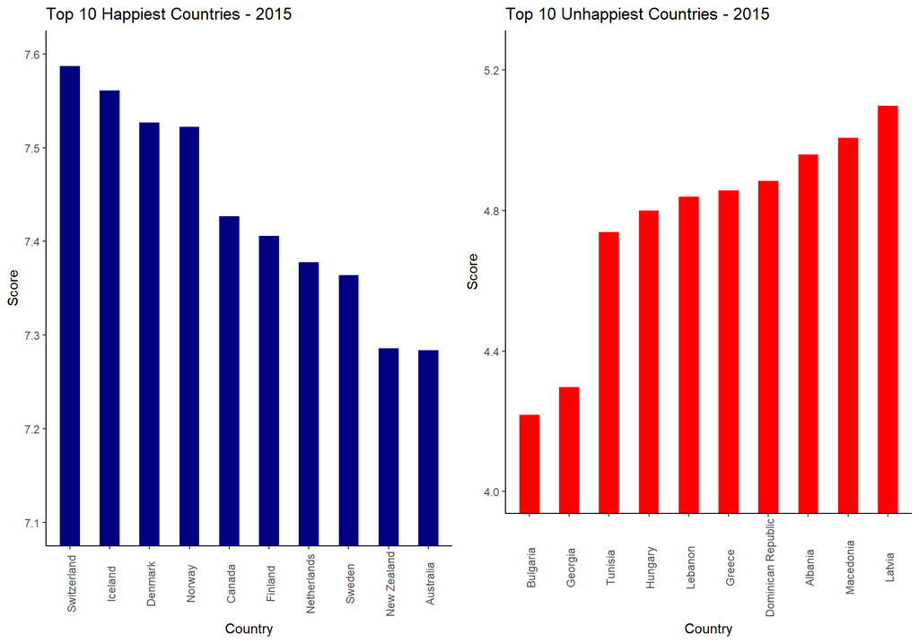

```r
dfData.ordered.high <- head(dfData.master[order(dfData.master$Happiness.Score, decreasing = TRUE),], n = 10)

g1 <- ggplot2::ggplot(
  dfData.ordered.high,
  ggplot2::aes(
    x=factor(Country,levels=dfData.ordered.high$Country[order(dfData.ordered.high$Happiness.Score, decreasing = TRUE)]),
  y=Happiness.Score))
g1 <- g1 + ggplot2::geom_bar(stat="identity",width=0.5,fill="navyblue")
g1 <- g1 + ggplot2::theme( axis.text.x = ggplot2::element_text(angle=90, vjust=0.6))
g1 <- g1 + ggplot2::labs(title="Top 10 Happiest Countries - 2015", x="Country",y="Score")
g1 <- g1 + ggplot2::coord_cartesian(ylim=c(7.1,7.6))


dfData.ordered.low <- tail(dfData.master[order(dfData.master$Happiness.Score, decreasing = TRUE),], n = 10)

g2 <- ggplot2::ggplot(
  dfData.ordered.low,
  ggplot2::aes(
    x=factor(Country,levels=dfData.ordered.low$Country[order(dfData.ordered.low$Happiness.Score, decreasing = FALSE)]),
  y=Happiness.Score))
g2 <- g2 + ggplot2::geom_bar(stat="identity",width=0.5,fill="red")
g2 <- g2 + ggplot2::theme( axis.text.x = ggplot2::element_text(angle=90, vjust=0.6))
g2 <- g2 + ggplot2::labs(title="Top 10 Unhappiest Countries - 2015", x="Country",y="Score")
g2 <- g2 + ggplot2::coord_cartesian(ylim=c(4,5.25))

gridExtra::grid.arrange(g1, g2,  ncol = 2,nrow=1)
```

#### GDP

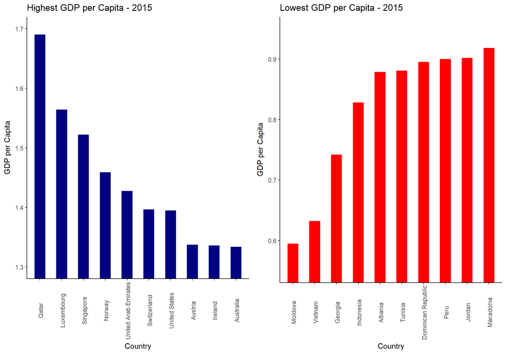

```r
dfData.ordered.high <- head(dfData.master[order(dfData.master$Economy.GDP.per.Capita, decreasing = TRUE),], n = 10)

g1 <- ggplot2::ggplot(
        dfData.ordered.high,
        ggplot2::aes(x=factor(dfData.ordered.high$Country,levels=dfData.ordered.high$Country[order(dfData.ordered.high$Economy.GDP.per.Capita, decreasing = TRUE)]),y=Economy.GDP.per.Capita)
      )
g1 <- g1 + ggplot2::geom_bar(stat="identity",width=0.5,fill="navyblue")
g1 <- g1 + ggplot2::theme(axis.text.x = ggplot2::element_text(angle=90, vjust=0.6))
g1 <- g1 + ggplot2::labs(title="Highest GDP per Capita - 2015", x="Country",y="GDP per Capita")
g1 <- g1 + ggplot2::coord_cartesian(ylim=c(1.3,1.7))

dfData.ordered.low <- tail(dfData.master[order(dfData.master$Economy.GDP.per.Capita, decreasing = TRUE),], n = 10)

g2 <- ggplot2::ggplot(
        dfData.ordered.low,
        ggplot2::aes(x=factor(dfData.ordered.low$Country,levels=dfData.ordered.low$Country[order(dfData.ordered.low$Economy.GDP.per.Capita, decreasing = FALSE)]),y=Economy.GDP.per.Capita)
        )
g2 <- g2 + ggplot2::geom_bar(stat="identity",width=0.5,fill="red")
g2 <- g2 + ggplot2::theme(axis.text.x = ggplot2::element_text(angle=90, vjust=0.6))
g2 <- g2 + ggplot2::labs(title="Lowest GDP per Capita - 2015", x="Country",y="GDP per Capita")
g2 <- g2 + ggplot2::coord_cartesian(ylim=c(0.55,0.95))

gridExtra::grid.arrange(g1, g2,  ncol = 2,nrow=1)
```

#### Health Life Expectancy

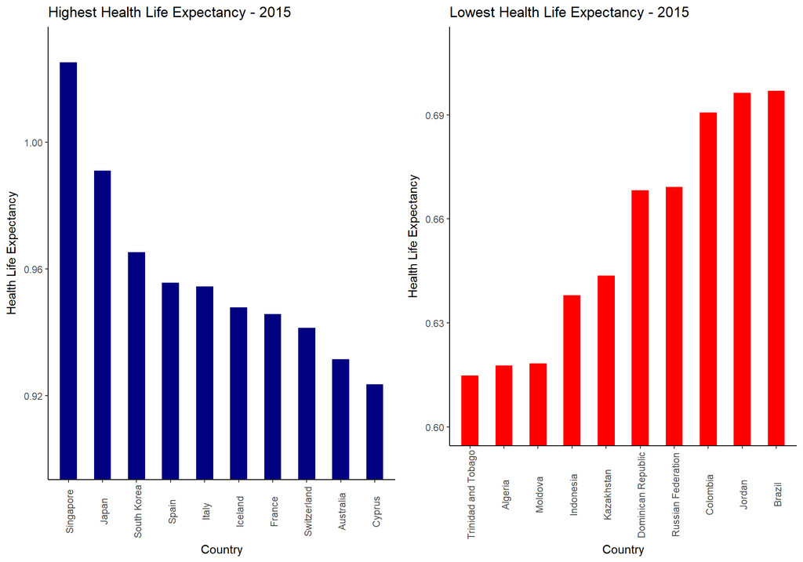

```r
dfData.ordered.high <- head(dfData.master[order(dfData.master$Health.Life.Expectancy, decreasing = TRUE),], n = 10)

g1 <- ggplot2::ggplot(
        dfData.ordered.high,
        ggplot2::aes(x=factor(dfData.ordered.high$Country,levels=dfData.ordered.high$Country[order(dfData.ordered.high$Health.Life.Expectancy, decreasing = TRUE)]),y=Health.Life.Expectancy)
      )
g1 <- g1 + ggplot2::geom_bar(stat="identity",width=0.5,fill="navyblue")
g1 <- g1 + ggplot2::theme(axis.text.x = ggplot2::element_text(angle=90, vjust=0.6))
g1 <- g1 + ggplot2::labs(title="Highest Health Life Expectancy - 2015", x="Country",y="Health Life Expectancy")
g1 <- g1 + ggplot2::coord_cartesian(ylim=c(0.9,1.03))

dfData.ordered.low <- tail(dfData.master[order(dfData.master$Health.Life.Expectancy, decreasing = TRUE),], n = 10)

g2 <- ggplot2::ggplot(
        dfData.ordered.low,
        ggplot2::aes(x=factor(dfData.ordered.low$Country,levels=dfData.ordered.low$Country[order(dfData.ordered.low$Health.Life.Expectancy, decreasing = FALSE)]),y=Health.Life.Expectancy)
        )
g2 <- g2 + ggplot2::geom_bar(stat="identity",width=0.5,fill="red")
g2 <- g2 + ggplot2::theme(axis.text.x = ggplot2::element_text(angle=90, vjust=0.6))
g2 <- g2 + ggplot2::labs(title="Lowest Health Life Expectancy - 2015", x="Country",y="Health Life Expectancy")
g2 <- g2 + ggplot2::coord_cartesian(ylim=c(0.6,0.71))

gridExtra::grid.arrange(g1, g2,  ncol = 2,nrow=1)
```

#### Alcohol Consumption

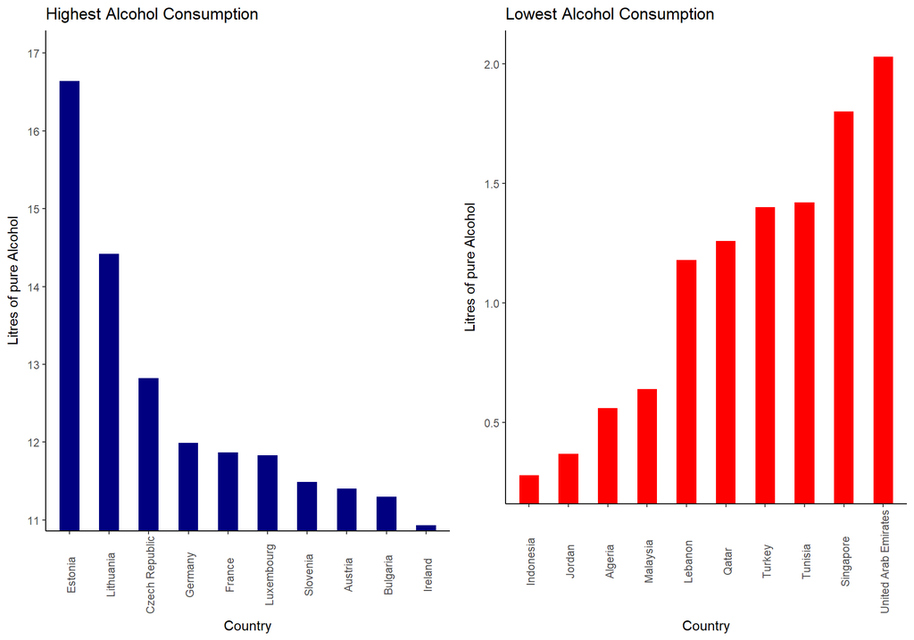

```r
dfData.ordered.high <- head(dfData.master[order(dfData.master$Alcohol.Consumption.All.Types, decreasing = TRUE),], n = 10)

g1 <- ggplot2::ggplot(
        dfData.ordered.high,
        ggplot2::aes(x=factor(dfData.ordered.high$Country,levels=dfData.ordered.high$Country[order(dfData.ordered.high$Alcohol.Consumption.All.Types, decreasing = TRUE)]),y=Alcohol.Consumption.All.Types)
      )
g1 <- g1 + ggplot2::geom_bar(stat="identity",width=0.5,fill="navyblue")
g1 <- g1 + ggplot2::theme(axis.text.x = ggplot2::element_text(angle=90, vjust=0.6))
g1 <- g1 + ggplot2::labs(title="Highest Alcohol Consumption", x="Country",y="Litres of pure Alcohol")
g1 <- g1 + ggplot2::coord_cartesian(ylim=c(11.15,17))

dfData.ordered.low <- tail(dfData.master[order(dfData.master$Alcohol.Consumption.All.Types, decreasing = TRUE),], n = 10)

g2 <- ggplot2::ggplot(
        dfData.ordered.low,
        ggplot2::aes(x=factor(dfData.ordered.low$Country,levels=dfData.ordered.low$Country[order(dfData.ordered.low$Alcohol.Consumption.All.Types, decreasing = FALSE)]),y=Alcohol.Consumption.All.Types)
        )
g2 <- g2 + ggplot2::geom_bar(stat="identity",width=0.5,fill="red")
g2 <- g2 + ggplot2::theme(axis.text.x = ggplot2::element_text(angle=90, vjust=0.6))
g2 <- g2 + ggplot2::labs(title="Lowest Alcohol Consumption", x="Country",y="Litres of pure Alcohol")
g2 <- g2 + ggplot2::coord_cartesian(ylim=c(0.25,2.05))

gridExtra::grid.arrange(g1, g2,  ncol = 2,nrow=1)
```

#### PISA Mean Performance

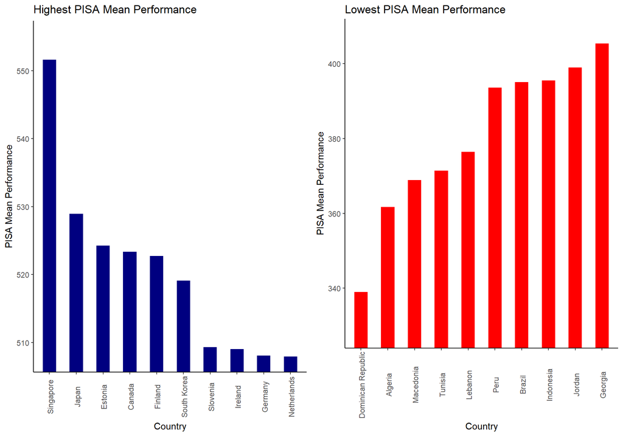

```r
dfData.ordered.high <- head(dfData.master[order(dfData.master$PISA.Performance.Mean, decreasing = TRUE),], n = 10)

g1 <- ggplot2::ggplot(
        dfData.ordered.high,
        ggplot2::aes(x=factor(dfData.ordered.high$Country,levels=dfData.ordered.high$Country[order(dfData.ordered.high$PISA.Performance.Mean, decreasing = TRUE)]),y=PISA.Performance.Mean)
      )
g1 <- g1 + ggplot2::geom_bar(stat="identity",width=0.5,fill="navyblue")
g1 <- g1 + ggplot2::theme(axis.text.x = ggplot2::element_text(angle=90, vjust=0.6))
g1 <- g1 + ggplot2::labs(title="Highest PISA Mean Performance", x="Country",y="PISA Mean Performance")
g1 <- g1 + ggplot2::coord_cartesian(ylim=c(508,555))

dfData.ordered.low <- tail(dfData.master[order(dfData.master$PISA.Performance.Mean, decreasing = TRUE),], n = 10)

g2 <- ggplot2::ggplot(
        dfData.ordered.low,
        ggplot2::aes(x=factor(dfData.ordered.low$Country,levels=dfData.ordered.low$Country[order(dfData.ordered.low$PISA.Performance.Mean, decreasing = FALSE)]),y=PISA.Performance.Mean)
        )
g2 <- g2 + ggplot2::geom_bar(stat="identity",width=0.5,fill="red")
g2 <- g2 + ggplot2::theme(axis.text.x = ggplot2::element_text(angle=90, vjust=0.6))
g2 <- g2 + ggplot2::labs(title="Lowest PISA Mean Performance", x="Country",y="PISA Mean Performance")
g2 <- g2 + ggplot2::coord_cartesian(ylim=c(328,408))

gridExtra::grid.arrange(g1, g2,  ncol = 2,nrow=1)
```

#### PISA Mean Performance Mathematics

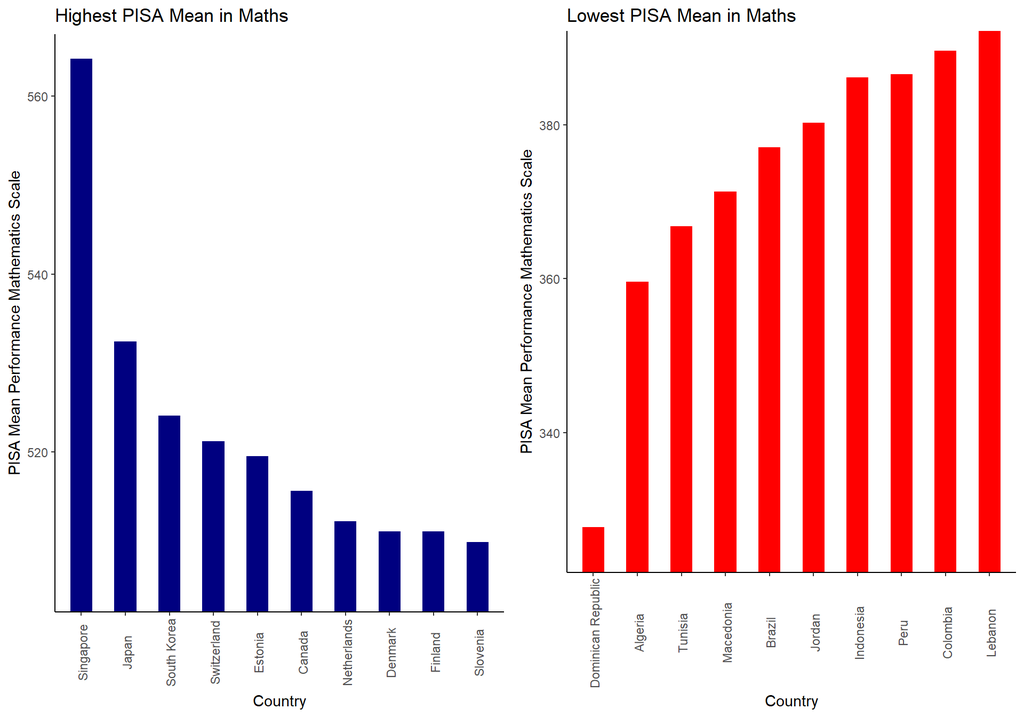

```r
dfData.ordered.high <- head(dfData.master[order(dfData.master$PISA.Performance.Mean.Mathematics, decreasing = TRUE),], n = 10)

g1 <- ggplot2::ggplot(
        dfData.ordered.high,
        ggplot2::aes(x=factor(dfData.ordered.high$Country,levels=dfData.ordered.high$Country[order(dfData.ordered.high$PISA.Performance.Mean.Mathematics, decreasing = TRUE)]),y=PISA.Performance.Mean.Mathematics)
      )
g1 <- g1 + ggplot2::geom_bar(stat="identity",width=0.5,fill="navyblue")
g1 <- g1 + ggplot2::theme(axis.text.x = ggplot2::element_text(angle=90, vjust=0.6))
g1 <- g1 + ggplot2::labs(title="Highest PISA Mean in Maths", x="Country",y="PISA Mean Performance Mathematics Scale")
g1 <- g1 + ggplot2::coord_cartesian(ylim=c(505,564))

dfData.ordered.low <- tail(dfData.master[order(dfData.master$PISA.Performance.Mean.Mathematics, decreasing = TRUE),], n = 10)

g2 <- ggplot2::ggplot(
        dfData.ordered.low,
        ggplot2::aes(x=factor(dfData.ordered.low$Country,levels=dfData.ordered.low$Country[order(dfData.ordered.low$PISA.Performance.Mean.Mathematics, decreasing = FALSE)]),y=PISA.Performance.Mean.Mathematics)
        )
g2 <- g2 + ggplot2::geom_bar(stat="identity",width=0.5,fill="red")
g2 <- g2 + ggplot2::theme(axis.text.x = ggplot2::element_text(angle=90, vjust=0.6))
g2 <- g2 + ggplot2::labs(title="Lowest PISA Mean in Maths", x="Country",y="PISA Mean Performance Mathematics Scale")
g2 <- g2 + ggplot2::coord_cartesian(ylim=c(325,389))

gridExtra::grid.arrange(g1, g2,  ncol = 2,nrow=1)
```

#### PISA Mean Performance Reading

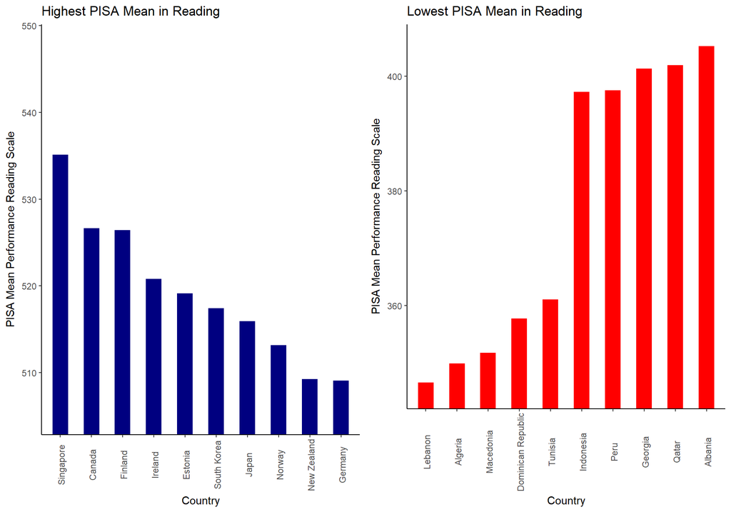

```r
dfData.ordered.high <- head(dfData.master[order(dfData.master$PISA.Performance.Mean.Reading, decreasing = TRUE),], n = 10)

g1 <- ggplot2::ggplot(
        dfData.ordered.high,
        ggplot2::aes(x=factor(dfData.ordered.high$Country,levels=dfData.ordered.high$Country[order(dfData.ordered.high$PISA.Performance.Mean.Reading, decreasing = TRUE)]),y=PISA.Performance.Mean.Reading)
      )
g1 <- g1 + ggplot2::geom_bar(stat="identity",width=0.5,fill="navyblue")
g1 <- g1 + ggplot2::theme(axis.text.x = ggplot2::element_text(angle=90, vjust=0.6))
g1 <- g1 + ggplot2::labs(title="Highest PISA Mean in Reading", x="Country",y="PISA Mean Performance Reading Scale")
g1 <- g1 + ggplot2::coord_cartesian(ylim=c(505,548))

dfData.ordered.low <- tail(dfData.master[order(dfData.master$PISA.Performance.Mean.Reading, decreasing = TRUE),], n = 10)

g2 <- ggplot2::ggplot(
        dfData.ordered.low,
        ggplot2::aes(x=factor(dfData.ordered.low$Country,levels=dfData.ordered.low$Country[order(dfData.ordered.low$PISA.Performance.Mean.Reading, decreasing = FALSE)]),y=PISA.Performance.Mean.Reading)
        )
g2 <- g2 + ggplot2::geom_bar(stat="identity",width=0.5,fill="red")
g2 <- g2 + ggplot2::theme(axis.text.x = ggplot2::element_text(angle=90, vjust=0.6))
g2 <- g2 + ggplot2::labs(title="Lowest PISA Mean in Reading", x="Country",y="PISA Mean Performance Reading Scale")
g2 <- g2 + ggplot2::coord_cartesian(ylim=c(345,406))

gridExtra::grid.arrange(g1, g2,  ncol = 2,nrow=1)
```

#### PISA Mean Performance Science

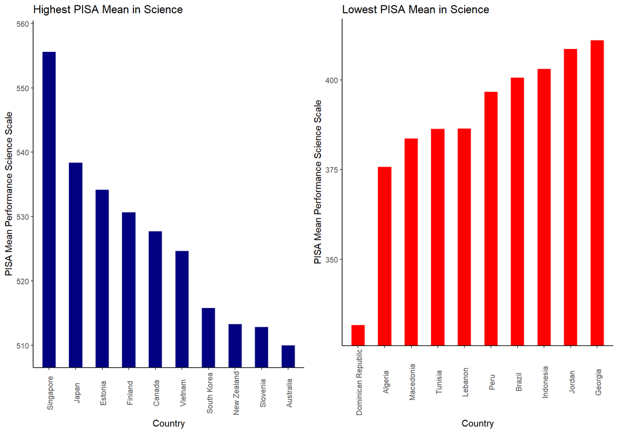

```r
dfData.ordered.high <- head(dfData.master[order(dfData.master$PISA.Performance.Mean.Science, decreasing = TRUE),], n = 10)

g1 <- ggplot2::ggplot(
        dfData.ordered.high,
        ggplot2::aes(x=factor(dfData.ordered.high$Country,levels=dfData.ordered.high$Country[order(dfData.ordered.high$PISA.Performance.Mean.Science, decreasing = TRUE)]),y=PISA.Performance.Mean.Science)
      )
g1 <- g1 + ggplot2::geom_bar(stat="identity",width=0.5,fill="navyblue")
g1 <- g1 + ggplot2::theme(axis.text.x = ggplot2::element_text(angle=90, vjust=0.6))
g1 <- g1 + ggplot2::labs(title="Highest PISA Mean in Science", x="Country",y="PISA Mean Performance Science Scale")
g1 <- g1 + ggplot2::coord_cartesian(ylim=c(509,558))

dfData.ordered.low <- tail(dfData.master[order(dfData.master$PISA.Performance.Mean.Science, decreasing = TRUE),], n = 10)

g2 <- ggplot2::ggplot(
        dfData.ordered.low,
        ggplot2::aes(x=factor(dfData.ordered.low$Country,levels=dfData.ordered.low$Country[order(dfData.ordered.low$PISA.Performance.Mean.Science, decreasing = FALSE)]),y=PISA.Performance.Mean.Science)
        )
g2 <- g2 + ggplot2::geom_bar(stat="identity",width=0.5,fill="red")
g2 <- g2 + ggplot2::theme(axis.text.x = ggplot2::element_text(angle=90, vjust=0.6))
g2 <- g2 + ggplot2::labs(title="Lowest PISA Mean in Science", x="Country",y="PISA Mean Performance Science Scale")
g2 <- g2 + ggplot2::coord_cartesian(ylim=c(330,413))

gridExtra::grid.arrange(g1, g2,  ncol = 2,nrow=1)
```

# Analysis

## Correlation and Regression Analysis

Now we want to find out how our chosen datasets correlate with each other and, if yes, whether the correlations are of significance. Therefore we will firstly perform a correlation analysis between all relevant variables to get a grasp on their overall relationship. Following that we will pick out the strongest ones to examine in a linear regression analysis.

### Setup

#### Read data

This will be the data we will work with in the following analysis.

| Country | Region | Happiness.Score | Happiness.Score.Standard.Error | Economy.GDP.per.Capita | Family | Health.Life.Expectancy | Freedom | Trust.Government.Corruption | Generosity | Dystopia.Residual | PISA.Performance.Mean.Mathematics | PISA.Performance.Mean.Reading | PISA.Performance.Mean.Science | PISA.Performance.Mean | Alcohol.Consumption.All.Types | Beer | Other | Spirits | Wine |
| --- | --- | --- | --- | --- | --- | --- | --- | --- | --- | --- | --- | --- | --- | --- | --- | --- | --- | --- | --- |
| Albania | Central and Eastern Europe | 4.959 | 0.05013 | 0.87867 | 0.80434 | 0.81325 | 0.35733 | 0.06413 | 0.14272 | 1.89894 | 413.1570 | 405.2588 | 427.2250 | 415.2136 | 4.77 | 1.57 | 0.08 | 1.94 | 1.17 |
| Algeria | Middle East and Northern Africa | 5.605 | 0.05099 | 0.93929 | 1.07772 | 0.61766 | 0.28579 | 0.17383 | 0.07822 | 2.43209 | 359.6062 | 349.8593 | 375.7451 | 361.7369 | 0.56 | 0.31 | 0.00 | 0.10 | 0.14 |
| Argentina | Latin America and Caribbean | 6.574 | 0.04612 | 1.05351 | 1.24823 | 0.78723 | 0.44974 | 0.08484 | 0.11451 | 2.83600 | 409.0333 | 425.3031 | 432.2262 | 422.1875 | 8.42 | 3.36 | 0.87 | 0.81 | 3.38 |
| Australia | Australia and New Zealand | 7.284 | 0.04083 | 1.33358 | 1.30923 | 0.93156 | 0.65124 | 0.35637 | 0.43562 | 2.26646 | 493.8962 | 502.9006 | 509.9939 | 502.2636 | 9.52 | 3.76 | 0.88 | 1.22 | 3.66 |
| Austria | Western Europe | 7.200 | 0.03751 | 1.33723 | 1.29704 | 0.89042 | 0.62433 | 0.18676 | 0.33088 | 2.53320 | 496.7423 | 484.8656 | 495.0375 | 492.2151 | 11.40 | 6.10 | NA | 1.70 | 3.60 |
| Belgium | Western Europe | 6.937 | 0.03595 | 1.30782 | 1.28566 | 0.89667 | 0.58450 | 0.22540 | 0.22250 | 2.41484 | 506.9844 | 498.5242 | 501.9997 | 502.5028 | 10.36 | 4.60 | 0.32 | 1.47 | 3.97 |
| Brazil | Latin America and Caribbean | 6.983 | 0.04076 | 0.98124 | 1.23287 | 0.69702 | 0.49049 | 0.17521 | 0.14574 | 3.26001 | 377.0695 | 407.3486 | 400.6821 | 395.0334 | 6.97 | 4.45 | 0.03 | 2.24 | 0.25 |
| Bulgaria | Central and Eastern Europe | 4.218 | 0.04828 | 1.01216 | 1.10614 | 0.76649 | 0.30587 | 0.00872 | 0.11921 | 0.89991 | 441.1899 | 431.7175 | 445.7720 | 439.5598 | 11.30 | 4.22 | 0.13 | 4.99 | 1.96 |
| Canada | North America | 7.427 | 0.03553 | 1.32629 | 1.32261 | 0.90563 | 0.63297 | 0.32957 | 0.45811 | 2.45176 | 515.6474 | 526.6678 | 527.7047 | 523.3400 | 8.00 | 3.70 | 0.30 | 2.00 | 2.00 |
| Chile | Latin America and Caribbean | 6.670 | 0.05800 | 1.10715 | 1.12447 | 0.85857 | 0.44132 | 0.12869 | 0.33363 | 2.67585 | 422.6714 | 458.5709 | 446.9561 | 442.7328 | 7.89 | 2.85 | 0.00 | 2.43 | 2.61 |

[output cut: 56 more lines]

### Correlation Analysis

– Select relevant columns for correlation

Since we are looking only at numeric variables during the correlation analysis we will sort out the columns “Country” and “Region”. The standard error of the Happiness Score will, too, be unnecessary for our following process. Since our used correlation plot package does not support label parameters yet, instead using column names by default, we will rename the column names. For, whereas precise column names are suitable in a dataset, they are too long as axis lables in the corrplot, making the plot distorted and convoluted.

```r
dfData.Master.Corr <- dplyr::select(dfData.Master, Happiness.Score, Economy.GDP.per.Capita, Family, Health.Life.Expectancy,Freedom, Trust.Government.Corruption, Generosity, Dystopia.Residual,Alcohol.Consumption.All.Types,Beer, Wine, Spirits, Other, dplyr::contains("PISA"))

dfData.Master.Corr<-dfData.Master.Corr%>%
  rename(Economy=Economy.GDP.per.Capita)%>%
  rename(Health=Health.Life.Expectancy)%>%
  rename(Corruption=Trust.Government.Corruption)%>%
  rename(Alc.All=Alcohol.Consumption.All.Types)%>%
  rename(Math=PISA.Performance.Mean.Mathematics)%>%
  rename(Reading=PISA.Performance.Mean.Reading)%>%
  rename(Science=PISA.Performance.Mean.Science)%>%
  rename(MeanPerf=PISA.Performance.Mean)
```

– Perform Correlation

```r
summary(cor(dfData.Master.Corr, use = "pairwise.complete.obs"))
```

```
##  Happiness.Score      Economy             Family           Health
##  Min.   :-0.1630   Min.   :-0.04411   Min.   :0.1562   Min.   :-0.1024
##  1st Qu.: 0.2791   1st Qu.: 0.24915   1st Qu.:0.2711   1st Qu.: 0.2451
##  Median : 0.5034   Median : 0.53684   Median :0.4850   Median : 0.4016
##  Mean   : 0.4483   Mean   : 0.44351   Mean   :0.4464   Mean   : 0.4258
##  3rd Qu.: 0.6196   3rd Qu.: 0.61290   3rd Qu.:0.5368   3rd Qu.: 0.6719
##  Max.   : 1.0000   Max.   : 1.00000   Max.   :1.0000   Max.   : 1.0000
##     Freedom          Corruption         Generosity
##  Min.   :-0.1573   Min.   :-0.19938   Min.   :-0.16495
##  1st Qu.: 0.1578   1st Qu.: 0.08036   1st Qu.: 0.07103
##  Median : 0.3617   Median : 0.31991   Median : 0.21260
##  Mean   : 0.3660   Mean   : 0.29646   Mean   : 0.26060
##  3rd Qu.: 0.5770   3rd Qu.: 0.42791   3rd Qu.: 0.39606
##  Max.   : 1.0000   Max.   : 1.00000   Max.   : 1.00000
##  Dystopia.Residual     Alc.All              Beer
##  Min.   :-0.19378   Min.   :-0.06137   Min.   :-0.05977
##  1st Qu.:-0.05318   1st Qu.: 0.14689   1st Qu.: 0.22298
##  Median : 0.01425   Median : 0.43298   Median : 0.32630
##  Mean   : 0.10475   Mean   : 0.39359   Mean   : 0.36115
##  3rd Qu.: 0.13384   3rd Qu.: 0.54663   3rd Qu.: 0.45314
##  Max.   : 1.00000   Max.   : 1.00000   Max.   : 1.00000
##       Wine            Spirits            Other
##  Min.   :-0.0665   Min.   :-0.1994   Min.   :-0.162583
##  1st Qu.: 0.1425   1st Qu.:-0.1573   1st Qu.: 0.006415
##  Median : 0.2495   Median : 0.1562   Median : 0.268530
##  Mean   : 0.2914   Mean   : 0.1549   Mean   : 0.222505
##  3rd Qu.: 0.3927   3rd Qu.: 0.2308   3rd Qu.: 0.364913
##  Max.   : 1.0000   Max.   : 1.0000   Max.   : 1.000000
##       Math             Reading           Science
##  Min.   :-0.05318   Min.   :0.05778   Min.   :-0.01779
##  1st Qu.: 0.32414   1st Qu.:0.34681   1st Qu.: 0.36355
##  Median : 0.42508   Median :0.50344   Median : 0.44192
##  Mean   : 0.51887   Mean   :0.53971   Mean   : 0.52266
##  3rd Qu.: 0.68472   3rd Qu.:0.67193   3rd Qu.: 0.66157
##  Max.   : 1.00000   Max.   :1.00000   Max.   : 1.00000
##     MeanPerf
##  Min.   :-0.00508
##  1st Qu.: 0.35384
##  Median : 0.46250
##  Mean   : 0.53393
##  3rd Qu.: 0.68192
##  Max.   : 1.00000
```

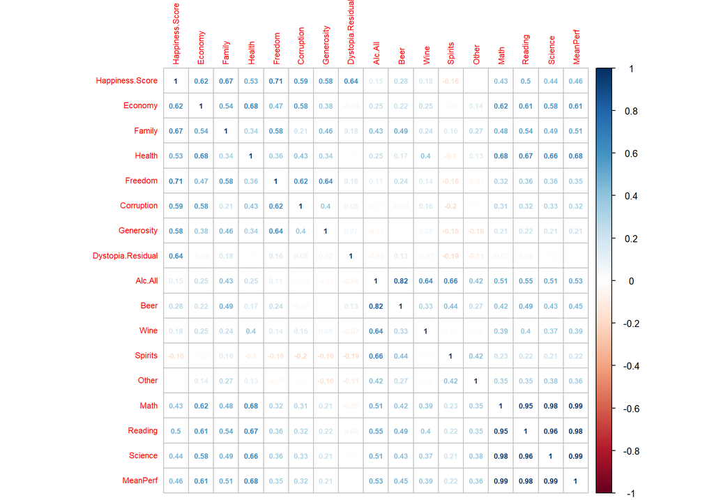

```r
corrplot::corrplot(cor(dfData.Master.Corr, use = "pairwise.complete.obs"), method="number",tl.cex = 0.7, number.digits = 2, number.cex = 0.6, addrect = 5)
```

#### Interpretation

Happiness dataset: As already seen during descriptive analysis, countries with a high happiness score tend to value freedom the most (0.71)

```r
lmPISA.Alcohol.Types <- lm(PISA.Performance.Mean ~Beer + Wine+ Spirits+Other, dfData.Master)
summary(lmPISA.Alcohol.Types)
```

```
##
## Call:
## lm(formula = PISA.Performance.Mean ~ Beer + Wine + Spirits +
##     Other, data = dfData.Master)
##
## Residuals:
##      Min       1Q   Median       3Q      Max
## -104.439  -22.750    2.049   24.136  125.480
##
## Coefficients:
##             Estimate Std. Error t value Pr(>|t|)
## (Intercept)  412.793     11.787  35.020   <2e-16 ***
## Beer           8.417      3.821   2.203   0.0317 *
## Wine           8.058      3.132   2.573   0.0127 *
## Spirits       -1.229      4.325  -0.284   0.7774
## Other         31.980     12.790   2.500   0.0153 *
## ---
## Signif. codes:  0 '***' 0.001 '**' 0.01 '*' 0.05 '.' 0.1 ' ' 1
##
## Residual standard error: 42.38 on 57 degrees of freedom
##   (4 observations deleted due to missingness)
## Multiple R-squared:  0.3406, Adjusted R-squared:  0.2943
## F-statistic: 7.359 on 4 and 57 DF,  p-value: 7.519e-05
```

```r
lmPISA.Alcohol.Main <- lm(PISA.Performance.Mean ~Alcohol.Consumption.All.Types, dfData.Master)
summary(lmPISA.Alcohol.Main)
```

```
##
## Call:
## lm(formula = PISA.Performance.Mean ~ Alcohol.Consumption.All.Types,
##     data = dfData.Master)
##
## Residuals:
##      Min       1Q   Median       3Q      Max
## -112.768  -32.917    1.351   24.665  130.073
##
## Coefficients:
##                               Estimate Std. Error t value Pr(>|t|)
## (Intercept)                    409.004     11.462  35.684  < 2e-16 ***
## Alcohol.Consumption.All.Types    6.969      1.396   4.991 4.88e-06 ***
## ---
## Signif. codes:  0 '***' 0.001 '**' 0.01 '*' 0.05 '.' 0.1 ' ' 1
##
## Residual standard error: 42.13 on 64 degrees of freedom
## Multiple R-squared:  0.2802, Adjusted R-squared:  0.2689
## F-statistic: 24.91 on 1 and 64 DF,  p-value: 4.885e-06
```

```r
lmPISA.Happiness <- lm(PISA.Performance.Mean~Happiness.Score, dfData.Master)
summary(lmPISA.Happiness)
```

```
##
## Call:
## lm(formula = PISA.Performance.Mean ~ Happiness.Score, data = dfData.Master)
##
## Residuals:
##     Min      1Q  Median      3Q     Max
## -88.436 -36.270   6.954  30.025  83.299
##
## Coefficients:
##                 Estimate Std. Error t value Pr(>|t|)
## (Intercept)      305.983     37.308   8.202 1.42e-11 ***
## Happiness.Score   24.868      5.959   4.173 9.24e-05 ***
## ---
## Signif. codes:  0 '***' 0.001 '**' 0.01 '*' 0.05 '.' 0.1 ' ' 1
##
## Residual standard error: 44.03 on 64 degrees of freedom
## Multiple R-squared:  0.2139, Adjusted R-squared:  0.2016
## F-statistic: 17.41 on 1 and 64 DF,  p-value: 9.241e-05
```

```r
lmHappiness.Alcohol <-lm(Happiness.Score ~ Alcohol.Consumption.All.Types, dfData.Master)
summary(lmHappiness.Alcohol)
```

```
##
## Call:
## lm(formula = Happiness.Score ~ Alcohol.Consumption.All.Types,
##     data = dfData.Master)
##
## Residuals:
##      Min       1Q   Median       3Q      Max
## -2.11942 -0.60885  0.04109  0.80203  1.37628
##
## Coefficients:
##                               Estimate Std. Error t value Pr(>|t|)
## (Intercept)                    5.93099    0.24853  23.864   <2e-16 ***
## Alcohol.Consumption.All.Types  0.03597    0.03028   1.188    0.239
## ---
## Signif. codes:  0 '***' 0.001 '**' 0.01 '*' 0.05 '.' 0.1 ' ' 1
##
## Residual standard error: 0.9136 on 64 degrees of freedom
## Multiple R-squared:  0.02158,    Adjusted R-squared:  0.006288
## F-statistic: 1.411 on 1 and 64 DF,  p-value: 0.2392
```

```r
lmPISA.Economy <- lm(PISA.Performance.Mean ~ Economy.GDP.per.Capita , dfData.Master)
summary(lmPISA.Economy)
```

```
##
## Call:
## lm(formula = PISA.Performance.Mean ~ Economy.GDP.per.Capita,
##     data = dfData.Master)
##
## Residuals:
##      Min       1Q   Median       3Q      Max
## -130.399  -18.452    0.201   22.930  116.270
##
## Coefficients:
##                        Estimate Std. Error t value Pr(>|t|)
## (Intercept)              294.92      27.04  10.906  3.1e-16 ***
## Economy.GDP.per.Capita   143.62      23.15   6.205  4.5e-08 ***
## ---
## Signif. codes:  0 '***' 0.001 '**' 0.01 '*' 0.05 '.' 0.1 ' ' 1
##
## Residual standard error: 39.24 on 64 degrees of freedom
## Multiple R-squared:  0.3756, Adjusted R-squared:  0.3659
## F-statistic: 38.51 on 1 and 64 DF,  p-value: 4.5e-08
```

### Regression Analysis

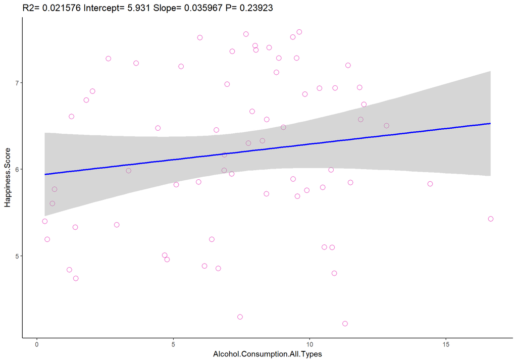

```r
plotRegression <- function(data){
  ggplot(data$model, aes_string(x=names(data$model)[2], y=names(data$model)[1]))+
    geom_point(shape=1, size=3, color="#DF01A5")+
    stat_smooth(method="lm", col="blue")+
    labs(title=paste("R2=", signif(summary(data)$r.squared,5),
                     "Intercept=", signif(data$coef[[1]],5),
                     "Slope=", signif(data$coef[[2]],5),
                     "P=",signif(summary(data)$coef[2,4],5)))
}

pHappiness.Alcohol<-plotRegression(lm(Happiness.Score~Alcohol.Consumption.All.Types, dfData.Master))

pPISA.Alcohol<-plotRegression(lm(PISA.Performance.Mean~Alcohol.Consumption.All.Types, dfData.Master))
pPISA.Happiness<-plotRegression(lm(PISA.Performance.Mean~Happiness.Score, dfData.Master))

pHappiness.Alcohol
```

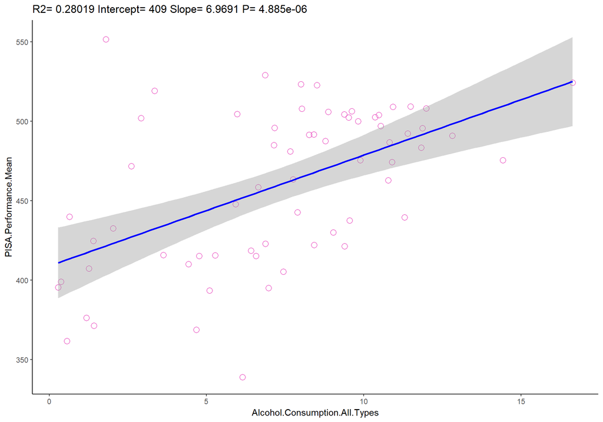

```r
pPISA.Alcohol
```

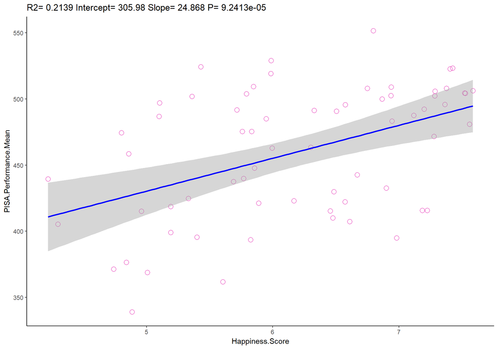

```r
pPISA.Happiness
```

#### Interpretation

High levels of significance point to positive relationships between our chosen variables:

– Different kinds of alcohol (Beer, Wine and Others especially) are significant predictor variables for the average PISA performance.  
– Alcohol consumption in general is a significant predictor variable for the average PISA performance.  
– The Happiness Score is a significant predictor for the average PISA performance.

However one has to consider the low levels of R-square in all of the aforementioned regressions. This means that, although the low P values indicate a real relationship between predictors and response variables, the precision of the prediction is not very high on all accounts. This can be led to the fact, that our data is very processed, on the one hand Happiness Score being a highly calculated variable and on the other having average scores for entire countries, rather than single oberservation variables.

Lack of significance for the relationship between Happiness Score and Alcohol Consumption.

# Conclusion

In general we can say that happier countries perform better at PISA. Countries with high alcohol consumption are not happier than countries with low alcohol consumption. And students who live in countries with high alcohol consumption perform better at PISA.

It is important to mention, that we cannot explain these correlations. In order to do so, further data and analysis would be needed, for example common influencial factors for PISA performance, alcohol consumption and happiness. Still the insights provided can be a basis for further investigation.